# Práctica computacional de estadística descriptiva en R

De una base simulada a dos bases reales completas: ambiente y salud clínica

Guía completa para RStudio

08/09/2026

# 1 Propósito de la práctica

Esta práctica desarrolla una secuencia completa de **estadística descriptiva y análisis exploratorio de datos en R**. La primera parte utiliza una encuesta simulada y controlada para introducir las herramientas fundamentales; la segunda parte transfiere el mismo protocolo de razonamiento a dos bases reales incluidas en un paquete de R.

La versión actual ha sido diseñada deliberadamente para un curso en el que **no se estudia todavía el tratamiento de datos faltantes**. Por esa razón, las dos bases reales seleccionadas son completas y el documento comprueba explícitamente esta condición antes de analizarlas.

El hilo conductor es:

> **comprender la unidad de análisis → reconocer los tipos de variables → verificar la estructura → resumir numéricamente → representar gráficamente → comparar grupos → explorar relaciones → integrar la evidencia en una interpretación estadística.**

La pregunta rectora es:

> **¿Cómo cambia nuestra descripción estadística cuando pasamos de una base simulada, cuyo mecanismo de generación conocemos, a bases reales completas cuya estructura y contexto debemos comprender antes de analizar?**

## 1.1 Resultados de aprendizaje

Al finalizar la práctica, el estudiante estará en capacidad de identificar variables cuantitativas y categóricas, construir resúmenes descriptivos globales y por grupos, seleccionar medidas de centro y dispersión coherentes con la forma de los datos, elegir visualizaciones pertinentes, explorar asociaciones entre variables cuantitativas y comunicar conclusiones descriptivas sustentadas simultáneamente en evidencia numérica y gráfica.

## 1.2 Bases reales seleccionadas

Para reemplazar las bases `Ozone` y `gm2004` utilizadas en la versión anterior se emplean dos conjuntos de datos menos habituales, ambos disponibles en el paquete `HSAUR3`:

- **`USairpollution`**: 41 ciudades de Estados Unidos y siete indicadores relacionados con contaminación por dióxido de azufre, clima, industria y población. Cada fila representa una ciudad.
- **`respiratory`**: 555 registros correspondientes a 111 pacientes de un ensayo clínico multicéntrico, observados en cinco momentos. Incluye centro, tratamiento, género, edad, estado respiratorio, mes y sujeto. La documentación oficial de `HSAUR3` declara explícitamente que no existen datos faltantes ni en la respuesta ni en las covariables. Esta base permite introducir, sin entrar todavía en técnicas de imputación, una idea metodológica valiosa: distinguir entre **fila**, **paciente** y **medición repetida**.

Estas bases son especialmente útiles porque permiten conservar los dos contextos del segundo script original —**ambiente** y **salud**— sin introducir todavía técnicas de manejo de datos incompletos.

# 2 Política de paquetes

La práctica mantiene una política minimalista:

- `dplyr`: única librería utilizada para **manipulación de bases de datos**.
- `ggplot2`: única librería utilizada para **visualización**.
- `HSAUR3`: se utiliza únicamente como **contenedor de las dos bases reales**; no se carga con `library()`.

Los estadísticos elementales se calculan con funciones de R base. De esta manera se evitan dependencias que duplican funcionalidades y se mantiene una sintaxis coherente durante toda la sesión.

```r
knitr::opts_chunk$set(echo = TRUE, message = FALSE, warning = FALSE, fig.width = 8.6, fig.height = 5.4) # Define opciones homogéneas para la presentación de todos los bloques de código.
repositorio_cran <- "https://cloud.r-project.org" # Fija un repositorio CRAN para que R no solicite elegir un servidor durante la compilación.
paquetes_analisis <- c("dplyr", "ggplot2") # Declara las dos librerías que se usarán directamente para manipular datos y construir gráficos.
paquetes_datos <- c("HSAUR3") # Declara el único paquete adicional requerido como contenedor de las dos bases reales.
paquetes_necesarios <- c(paquetes_analisis, paquetes_datos) # Reúne todas las dependencias que debe tener el documento para compilarse de principio a fin.
paquetes_faltantes <- paquetes_necesarios[!vapply(paquetes_necesarios, requireNamespace, logical(1), quietly = TRUE)] # Detecta cuáles paquetes todavía no están instalados sin cargarlos al entorno.
if (length(paquetes_faltantes) > 0) install.packages(paquetes_faltantes, repos = repositorio_cran) # Instala únicamente las dependencias ausentes y evita reinstalar las que ya existen.
paquetes_aun_faltantes <- paquetes_necesarios[!vapply(paquetes_necesarios, requireNamespace, logical(1), quietly = TRUE)] # Verifica que la instalación automática haya dejado disponibles todas las dependencias.
if (length(paquetes_aun_faltantes) > 0) stop(paste0("No fue posible instalar: ", paste(paquetes_aun_faltantes, collapse = ", "), ". Revise la conexión a Internet o los permisos de instalación de RStudio.")) # Detiene la compilación únicamente si una dependencia continúa ausente y comunica una causa probable.
library(dplyr) # Carga dplyr como única librería destinada al manejo de las bases de datos.
library(ggplot2) # Carga ggplot2 como único sistema gráfico de la práctica.
paleta_genero <- c("Femenino" = "#D81B60", "Masculino" = "#1E88E5") # Define una paleta contrastante para distinguir las dos categorías de género de la encuesta simulada.
paleta_ciudades <- c("Bogotá" = "#0072B2", "Medellín" = "#E69F00", "Cali" = "#009E73", "Barranquilla" = "#CC79A7", "Pasto" = "#D55E00", "Manizales" = "#56B4E9") # Define colores diferenciables para las seis ciudades de la encuesta.
paleta_tratamiento <- c("placebo" = "#E64B35", "treatment" = "#00A087") # Define colores contrastantes para distinguir los dos brazos del ensayo respiratorio.
paleta_estado <- c("poor" = "#D73027", "good" = "#1A9850") # Define una codificación semántica: rojo para estado respiratorio pobre y verde para estado bueno.
paleta_genero_resp <- c("female" = "#CC79A7", "male" = "#0072B2") # Define colores diferenciables para visualizar el género cuando añade una dimensión informativa.
```

### 2.0.1 Lectura de la configuración

El estudiante solo necesita aprender dos gramáticas de trabajo: `dplyr` para transformar y resumir información, y `ggplot2` para representarla. `HSAUR3` no añade una sintaxis nueva: simplemente permite cargar los conjuntos de datos mediante `data(..., package = "HSAUR3")`.

Las paletas se declaran una sola vez para mantener coherencia visual. Los colores no son decorativos: se utilizan cuando una categoría o grupo forma parte de la pregunta estadística. Cuando el color repite exactamente la información del eje, se evita una leyenda redundante; cuando representa una dimensión adicional, la leyenda se conserva.

# 3 Organización sugerida para 100 minutos

| Tiempo | Fase | Producto esperado |
| --- | --- | --- |
| 0–8 min | Activación y pregunta rectora | Identificación de unidad de análisis y tipos de variables |
| 8–20 min | Construcción e inspección de la encuesta | Lectura correcta de estructura y tipos |
| 20–38 min | Descriptiva cuantitativa | Resumen de edad y tabla de frecuencias agrupadas |
| 38–53 min | Visualización | Histograma/densidad, boxplot y dispersión |
| 53–63 min | Variables categóricas y grupos | Frecuencias y comparación por ciudad |
| 63–68 min | Transición a datos reales completos | Verificación de completitud y contexto |
| 68–90 min | Reto A o Reto B | Resumen, dos o tres gráficos e interpretación |
| 90–97 min | Contraste entre rutas | Comparación de decisiones analíticas |
| 97–100 min | Cierre | Exit ticket de tres respuestas |

# 4 Parte I. Práctica guiada: encuesta simulada

## 4.1 1. Construcción de la base de datos

Se conserva la estructura conceptual del primer script: 80 observaciones con ciudad, edad, estatura, peso y género. La simulación se hace un poco más realista que en el código original: edad, estatura y peso no se generan de manera uniforme, y se introduce deliberadamente una asociación entre estatura y peso.

La base sigue siendo **puramente didáctica** y no representa una muestra probabilística de la población colombiana.

```r
set.seed(2402) # Fija una semilla para obtener exactamente la misma muestra cada vez que se compile el documento.
n <- 80 # Define el número total de observaciones de la encuesta simulada.
ciudades_posibles <- c("Bogotá", "Medellín", "Cali", "Barranquilla", "Pasto", "Manizales") # Declara las seis categorías posibles para la variable ciudad.
generos_posibles <- c("Masculino", "Femenino") # Declara las dos categorías de género utilizadas en la simulación.
ciudad <- sample(ciudades_posibles, size = n, replace = TRUE) # Asigna aleatoriamente una ciudad a cada una de las 80 personas simuladas.
genero <- sample(generos_posibles, size = n, replace = TRUE) # Asigna aleatoriamente una categoría de género a cada observación.
edad <- round(rnorm(n, mean = 36, sd = 11)) # Genera edades alrededor de 36 años con dispersión moderada.
edad <- pmin(pmax(edad, 18), 65) # Restringe la edad al intervalo didáctico entre 18 y 65 años.
estatura <- ifelse(genero == "Masculino", rnorm(n, mean = 1.74, sd = 0.07), rnorm(n, mean = 1.62, sd = 0.065)) # Genera estaturas con centros diferentes por género para producir una estructura grupal visible.
estatura <- round(pmin(pmax(estatura, 1.45), 1.95), 2) # Restringe la estatura a valores plausibles y conserva dos decimales.
peso <- 22.8 * estatura^2 + rnorm(n, mean = 0, sd = 8) # Construye el peso alrededor de una relación con la estatura e incorpora variabilidad individual.
peso <- round(pmin(pmax(peso, 45), 110), 1) # Restringe los pesos a un rango plausible y conserva una cifra decimal.
encuesta <- data.frame(ciudad = factor(ciudad), edad = edad, estatura = estatura, peso = peso, genero = factor(genero)) # Integra las cinco variables en un único data.frame con las categorías tipificadas como factores.
total_faltantes_encuesta <- sum(is.na(encuesta)) # Cuenta los valores faltantes de toda la base simulada para comprobar que el ejercicio parte de datos completos.
```

### 4.1.1 Análisis del resultado

La base tiene **80 filas y 5 columnas**, y contiene **0 valores faltantes**. Cada fila representa una persona simulada y cada columna una característica observada. Esta distinción es la primera decisión estadística importante: antes de calcular una media debemos saber cuál es la unidad estadística y qué significa cada variable.

`ciudad` y `genero` son cualitativas; `edad`, `estatura` y `peso` son cuantitativas. La simulación incorpora una relación estructural entre estatura y peso y una diferencia de estatura por género. Por ello, cuando aparezcan asociaciones en los gráficos posteriores sabremos que algunas fueron introducidas por el mecanismo generador. Esta ventaja desaparece cuando pasemos a datos reales: allí tendremos que interpretar patrones sin conocer el mecanismo que los produjo.

## 4.2 2. Reconocimiento inicial de la base

```r
names(encuesta) # Muestra los nombres exactos de las cinco variables disponibles.
```

```
## [1] "ciudad"   "edad"     "estatura" "peso"     "genero"
```

```r
dim(encuesta) # Devuelve el número de filas y de columnas de la base.
```

```
## [1] 80  5
```

```r
str(encuesta) # Informa la clase del objeto y el tipo computacional asignado a cada variable.
```

```
## 'data.frame':    80 obs. of  5 variables:
##  $ ciudad  : Factor w/ 6 levels "Barranquilla",..: 3 1 4 2 2 1 6 2 6 4 ...
##  $ edad    : num  33 39 18 38 31 30 21 33 40 25 ...
##  $ estatura: num  1.72 1.78 1.64 1.5 1.56 1.68 1.67 1.88 1.54 1.78 ...
##  $ peso    : num  69 80.1 67.9 53.8 52.4 59.8 52.9 82.9 45 81.1 ...
##  $ genero  : Factor w/ 2 levels "Femenino","Masculino": 2 2 1 1 1 2 1 2 1 2 ...
```

```r
glimpse(encuesta) # Presenta una vista compacta de la estructura y de algunos valores mediante dplyr.
```

```
## Rows: 80
## Columns: 5
## $ ciudad   <fct> Cali, Barranquilla, Manizales, Bogotá, Bogotá, Barranquilla, …
## $ edad     <dbl> 33, 39, 18, 38, 31, 30, 21, 33, 40, 25, 26, 25, 18, 28, 48, 3…
## $ estatura <dbl> 1.72, 1.78, 1.64, 1.50, 1.56, 1.68, 1.67, 1.88, 1.54, 1.78, 1…
## $ peso     <dbl> 69.0, 80.1, 67.9, 53.8, 52.4, 59.8, 52.9, 82.9, 45.0, 81.1, 5…
## $ genero   <fct> Masculino, Masculino, Femenino, Femenino, Femenino, Masculino…
```

```r
head(encuesta, 6) # Muestra las primeras seis observaciones para inspeccionar el contenido de las columnas.
```

|  | ciudad | edad | estatura | peso | genero |
| --- | --- | --- | --- | --- | --- |
| 1 | Cali | 33 | 1.72 | 69.0 | Masculino |
| 2 | Barranquilla | 39 | 1.78 | 80.1 | Masculino |
| 3 | Manizales | 18 | 1.64 | 67.9 | Femenino |
| 4 | Bogotá | 38 | 1.50 | 53.8 | Femenino |
| 5 | Bogotá | 31 | 1.56 | 52.4 | Femenino |
| 6 | Barranquilla | 30 | 1.68 | 59.8 | Masculino |

```r
tail(encuesta, 6) # Muestra las últimas seis observaciones para complementar la inspección de la base.
```

|  | ciudad | edad | estatura | peso | genero |
| --- | --- | --- | --- | --- | --- |
| 75 | Bogotá | 41 | 1.75 | 61.3 | Masculino |
| 76 | Barranquilla | 19 | 1.84 | 67.3 | Masculino |
| 77 | Medellín | 35 | 1.71 | 58.1 | Masculino |
| 78 | Pasto | 22 | 1.61 | 71.5 | Femenino |
| 79 | Medellín | 37 | 1.77 | 82.5 | Masculino |
| 80 | Manizales | 33 | 1.64 | 65.5 | Femenino |

```r
summary(encuesta) # Produce un resumen automático adaptado al tipo de cada variable.
```

```
##           ciudad        edad          estatura          peso
##  Barranquilla:11   Min.   :18.00   Min.   :1.470   Min.   :45.00
##  Bogotá      :16   1st Qu.:27.00   1st Qu.:1.597   1st Qu.:55.55
##  Cali        :10   Median :33.00   Median :1.660   Median :64.35
##  Manizales   :18   Mean   :33.56   Mean   :1.676   Mean   :64.61
##  Medellín    :13   3rd Qu.:39.00   3rd Qu.:1.752   3rd Qu.:71.53
##  Pasto       :12   Max.   :56.00   Max.   :1.920   Max.   :84.70
##        genero
##  Femenino :39
##  Masculino:41
##
##
##
##
```

### 4.2.1 Análisis del resultado

`str()` y `glimpse()` deben confirmar que R interpreta `ciudad` y `genero` como factores y las otras tres variables como numéricas. Esa comprobación evita errores conceptuales como calcular una media de códigos categóricos.

`summary()` ofrece una primera panorámica, pero no debe confundirse con un análisis terminado. Para variables cuantitativas entrega medidas de posición y extremos; para factores entrega frecuencias. El siguiente paso será construir resúmenes orientados por preguntas específicas, con medidas seleccionadas conscientemente.

## 4.3 3. Centro, dispersión y posición de la edad

```r
resumen_edad <- encuesta |> # Toma la encuesta simulada como punto de partida del resumen.
  summarise( # Reduce las 80 observaciones a una fila de medidas descriptivas.
    n = n(), # Cuenta el número de personas de la muestra.
    media = mean(edad), # Calcula la media aritmética de la edad.
    mediana = median(edad), # Calcula la mediana de la distribución de edades.
    desviacion_estandar = sd(edad), # Calcula la desviación estándar muestral.
    minimo = min(edad), # Obtiene la menor edad observada.
    q1 = quantile(edad, 0.25), # Calcula el primer cuartil.
    q3 = quantile(edad, 0.75), # Calcula el tercer cuartil.
    maximo = max(edad), # Obtiene la mayor edad observada.
    IQR = IQR(edad) # Calcula el rango intercuartílico del 50 por ciento central de la distribución.
  ) # Cierra la construcción del resumen descriptivo.
resumen_edad # Imprime la tabla de resultados para facilitar su lectura.
```

| n | media | mediana | desviacion_estandar | minimo | q1 | q3 | maximo | IQR |
| --- | --- | --- | --- | --- | --- | --- | --- | --- |
| 80 | 33.5625 | 33 | 9.44383 | 18 | 27 | 39 | 56 | 12 |

### 4.3.1 Análisis del resultado

La edad media es aproximadamente **33.6 años**, mientras que la mediana es **33 años**. La diferencia absoluta entre ambas es de **0.6 años**. Esta comparación es una primera señal sobre la forma: una distancia pequeña entre media y mediana es compatible con una distribución aproximadamente equilibrada, aunque no constituye por sí sola una prueba de simetría.

La desviación estándar es **9.4 años** y el 50 % central de las observaciones se encuentra entre **27** y **39 años**. Estas dos medidas de dispersión responden a preguntas diferentes: la desviación estándar utiliza todas las observaciones y es sensible a extremos; el IQR se concentra en la mitad central y es más robusto.

## 4.4 4. Moda de una variable discreta

```r
frecuencia_edades <- encuesta |> # Parte de todas las observaciones de la encuesta.
  count(edad, name = "frecuencia", sort = TRUE) # Cuenta cuántas veces aparece cada edad y ordena los conteos de mayor a menor.
moda_edad <- frecuencia_edades |> # Toma la tabla de frecuencias de edades.
  slice_max(order_by = frecuencia, n = 1, with_ties = TRUE) # Conserva todas las edades que comparten la frecuencia máxima.
moda_edad # Muestra la moda o las modas en caso de empate.
```

| edad | frecuencia |
| --- | --- |
| 33 | 6 |

### 4.4.1 Análisis del resultado

La moda debe leerse junto con su frecuencia. En una muestra de solo 80 personas, que una edad sea la más repetida no significa que exista necesariamente un pico poblacional importante. Si aparecen varias modas, el empate es información y no un inconveniente que deba eliminarse seleccionando arbitrariamente una de ellas.

Este ejemplo permite diferenciar tres ideas de centro: la media equilibra magnitudes, la mediana identifica la posición central en datos ordenados y la moda identifica el valor observado con mayor frecuencia.

## 4.5 5. Tabla de frecuencias agrupadas con Sturges

```r
cortes_edad <- hist(encuesta$edad, breaks = "Sturges", plot = FALSE)$breaks # Obtiene los límites de clase propuestos por la regla de Sturges sin dibujar el histograma.
tabla_edad <- encuesta |> # Parte de las observaciones individuales de edad.
  mutate(clase_edad = cut(edad, breaks = cortes_edad, include.lowest = TRUE, right = TRUE)) |> # Asigna cada edad al intervalo de clase correspondiente.
  count(clase_edad, name = "frecuencia") |> # Cuenta el número de observaciones dentro de cada intervalo.
  mutate( # Añade frecuencias relativas y acumuladas a la tabla.
    frecuencia_relativa = frecuencia / sum(frecuencia), # Convierte los conteos en proporciones del total.
    porcentaje = 100 * frecuencia_relativa, # Expresa la frecuencia relativa en porcentaje.
    frecuencia_acumulada = cumsum(frecuencia), # Acumula progresivamente los conteos absolutos.
    porcentaje_acumulado = 100 * cumsum(frecuencia_relativa) # Acumula progresivamente la proporción y la expresa en porcentaje.
  ) # Cierra la construcción de las columnas adicionales.
tabla_edad # Muestra la tabla de distribución agrupada.
```

| clase_edad | frecuencia | frecuencia_relativa | porcentaje | frecuencia_acumulada | porcentaje_acumulado |
| --- | --- | --- | --- | --- | --- |
| [15,20] | 10 | 0.1250 | 12.50 | 10 | 12.50 |
| (20,25] | 8 | 0.1000 | 10.00 | 18 | 22.50 |
| (25,30] | 10 | 0.1250 | 12.50 | 28 | 35.00 |
| (30,35] | 18 | 0.2250 | 22.50 | 46 | 57.50 |
| (35,40] | 18 | 0.2250 | 22.50 | 64 | 80.00 |
| (40,45] | 9 | 0.1125 | 11.25 | 73 | 91.25 |
| (45,50] | 3 | 0.0375 | 3.75 | 76 | 95.00 |
| (50,55] | 2 | 0.0250 | 2.50 | 78 | 97.50 |
| (55,60] | 2 | 0.0250 | 2.50 | 80 | 100.00 |

### 4.5.1 Análisis del resultado

Agrupar datos continuos o discretos con muchos valores distintos reduce detalle, pero hace visible la arquitectura global de la distribución. La regla de Sturges ofrece un punto de partida para decidir el número de clases; no debe interpretarse como una regla obligatoria.

La frecuencia acumulada permite responder preguntas de posición del tipo “¿cuántas personas tienen una edad no superior al límite de esta clase?”. La frecuencia relativa facilita comparaciones entre muestras de tamaños diferentes porque estandariza los conteos respecto al total.

## 4.6 6. Asimetría y exceso de curtosis sin paquetes adicionales

```r
coef_asimetria <- function(x) { # Define una función reutilizable para calcular asimetría mediante momentos centrales.
  media_x <- mean(x) # Calcula la media de la variable recibida.
  m2 <- mean((x - media_x)^2) # Calcula el segundo momento central.
  m3 <- mean((x - media_x)^3) # Calcula el tercer momento central.
  m3 / (m2^(3 / 2)) # Devuelve el tercer momento central estandarizado.
} # Cierra la función de asimetría.
exceso_curtosis <- function(x) { # Define una función reutilizable para calcular exceso de curtosis.
  media_x <- mean(x) # Calcula la media de la variable recibida.
  m2 <- mean((x - media_x)^2) # Calcula el segundo momento central.
  m4 <- mean((x - media_x)^4) # Calcula el cuarto momento central.
  m4 / (m2^2) - 3 # Estandariza el cuarto momento y resta tres para expresarlo como exceso de curtosis.
} # Cierra la función de exceso de curtosis.
asimetria_edad <- coef_asimetria(encuesta$edad) # Calcula la asimetría de las edades simuladas.
curtosis_edad <- exceso_curtosis(encuesta$edad) # Calcula el exceso de curtosis de las edades simuladas.
asimetria_edad # Imprime el coeficiente de asimetría.
```

```
## [1] 0.2476844
```

```r
curtosis_edad # Imprime el exceso de curtosis.
```

```
## [1] -0.2320075
```

### 4.6.1 Análisis del resultado

La asimetría observada es **0.25**. Su signo indica hacia qué lado se extiende relativamente más la distribución: valores positivos sugieren mayor cola derecha y valores negativos mayor cola izquierda. La magnitud debe interpretarse conjuntamente con el histograma y la distancia entre media y mediana, no mediante un umbral rígido aislado.

El exceso de curtosis es **-0.23**. Un valor cercano a cero indica una concentración y unas colas comparables, en términos de cuarto momento, con la referencia normal; valores positivos o negativos describen diferencias respecto a esa referencia. En una muestra pequeña, estos coeficientes pueden variar apreciablemente y deben considerarse descriptores complementarios.

## 4.7 7. Histograma y densidad de la edad

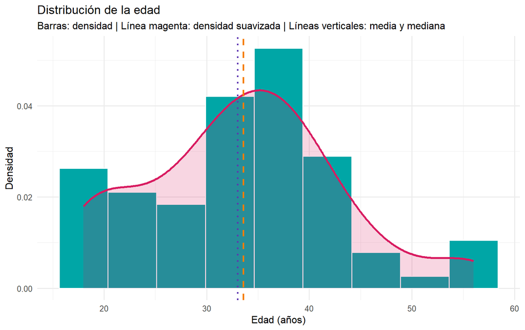

Distribución de la edad en la muestra simulada.

```r
numero_clases_edad <- length(cortes_edad) - 1 # Calcula el número de intervalos producido por la regla de Sturges.
ggplot(encuesta, aes(x = edad)) + # Inicia el gráfico utilizando la edad en el eje horizontal.
  geom_histogram(aes(y = after_stat(density)), bins = numero_clases_edad, fill = "#00A6A6", color = "white", linewidth = 0.6) + # Dibuja un histograma de densidad con un color turquesa intenso y bordes blancos.
  geom_density(color = "#D81B60", fill = "#D81B60", alpha = 0.18, linewidth = 1.2) + # Superpone una curva de densidad magenta para visualizar la forma suavizada.
  geom_vline(xintercept = resumen_edad$media, color = "#F57C00", linetype = "dashed", linewidth = 1) + # Añade una línea naranja en la media para relacionar forma y centro.
  geom_vline(xintercept = resumen_edad$mediana, color = "#5E35B1", linetype = "dotted", linewidth = 1) + # Añade una línea morada en la mediana para comparar ambas medidas de centro.
  labs(title = "Distribución de la edad", subtitle = "Barras: densidad | Línea magenta: densidad suavizada | Líneas verticales: media y mediana", x = "Edad (años)", y = "Densidad") + # Incorpora un título y un subtítulo que explican los elementos visuales.
  theme_minimal(base_size = 12) # Aplica un tema limpio y aumenta ligeramente el tamaño base de los textos.
```

### 4.7.1 Análisis del gráfico

El histograma muestra la distribución completa y permite evaluar cuestiones que una media no puede responder: concentración, número de zonas de alta frecuencia, posibles colas y huecos. La densidad suavizada facilita reconocer la forma global, aunque su aspecto depende del procedimiento de suavizado y no debe confundirse con una función de densidad teórica conocida.

Las líneas verticales permiten confrontar directamente la forma con el centro. Si media y mediana aparecen próximas y el histograma presenta masas relativamente equilibradas a ambos lados, ambas evidencias son coherentes. Si se separan, conviene investigar qué parte de la distribución está desplazando la media.

## 4.8 8. Edad por género

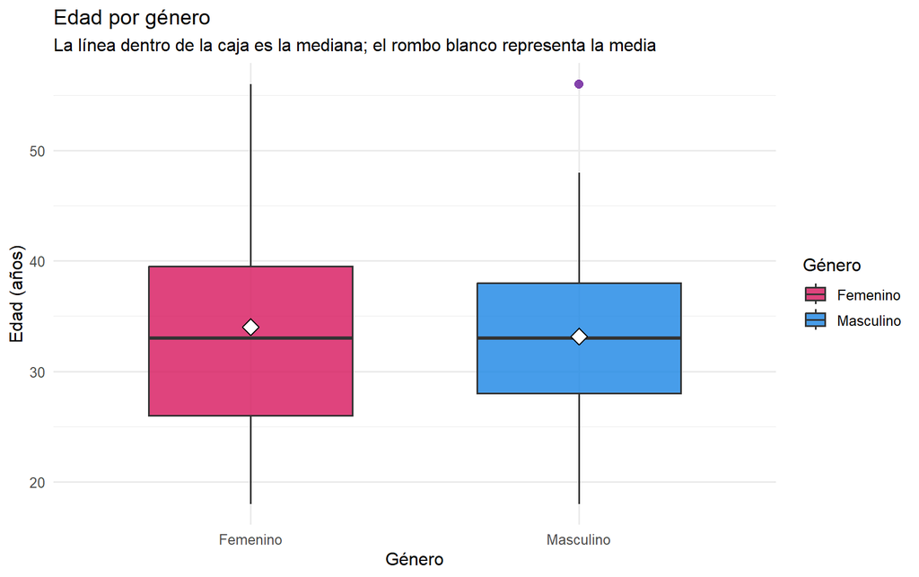

Distribución de edad por género en la muestra simulada.

```r
ggplot(encuesta, aes(x = genero, y = edad, fill = genero)) + # Inicia un boxplot de edad y asigna un color a cada categoría de género.
  geom_boxplot(alpha = 0.82, width = 0.62, outlier.color = "#6A1B9A", outlier.size = 2.5) + # Dibuja las cajas y resalta posibles valores extremos en morado.
  stat_summary(fun = mean, geom = "point", shape = 23, size = 3.8, fill = "white", color = "black") + # Superpone la media de cada grupo como un rombo blanco con borde negro.
  scale_fill_manual(values = paleta_genero, name = "Género") + # Aplica la paleta definida para diferenciar los dos grupos y genera una leyenda clara.
  labs(title = "Edad por género", subtitle = "La línea dentro de la caja es la mediana; el rombo blanco representa la media", x = "Género", y = "Edad (años)") + # Explica el significado estadístico de los principales elementos del gráfico.
  theme_minimal(base_size = 12) # Mantiene una presentación académica limpia.
```

### 4.8.1 Análisis del gráfico

La comparación no debe reducirse a identificar cuál media es mayor. El boxplot permite comparar simultáneamente mediana, rango intercuartílico, extensión de los bigotes y posibles observaciones extremas. Debido a que género y edad se generaron independientemente, una diferencia visible en edad entre categorías refleja variabilidad aleatoria de esta muestra, no una estructura incorporada al mecanismo de simulación.

Esta distinción es pedagógicamente importante: **una diferencia descriptiva observada no implica automáticamente una diferencia poblacional ni una relación causal**.

## 4.9 9. Relación entre estatura y peso

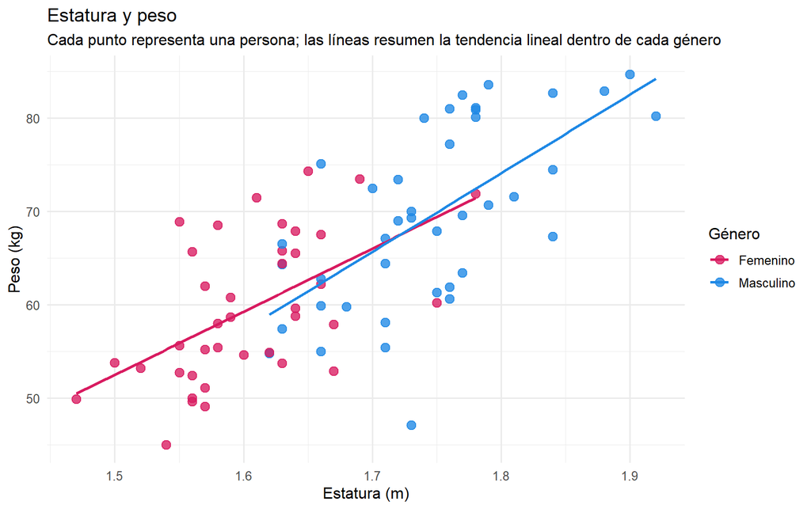

Relación entre estatura y peso, diferenciada por género.

```r
ggplot(encuesta, aes(x = estatura, y = peso, color = genero)) + # Inicia la nube de puntos y utiliza el color para identificar el género de cada observación.
  geom_point(size = 3, alpha = 0.78) + # Dibuja cada persona como un punto suficientemente visible y con ligera transparencia.
  geom_smooth(method = "lm", se = FALSE, linewidth = 1) + # Añade una recta descriptiva separada para cada género porque el color forma parte de la estética.
  scale_color_manual(values = paleta_genero, name = "Género") + # Aplica colores contrastantes y conserva la leyenda porque el color añade información no presente en los ejes.
  labs(title = "Estatura y peso", subtitle = "Cada punto representa una persona; las líneas resumen la tendencia lineal dentro de cada género", x = "Estatura (m)", y = "Peso (kg)") + # Explica la unidad de análisis y el significado de las líneas.
  theme_minimal(base_size = 12) # Aplica una presentación consistente.
```

```r
matriz_correlacion <- encuesta |> # Parte de la encuesta completa.
  select(edad, estatura, peso) |> # Conserva exclusivamente las tres variables cuantitativas de interés.
  cor() # Calcula la matriz de correlaciones de Pearson porque la base no contiene valores faltantes.
round(matriz_correlacion, 3) # Redondea los coeficientes a tres decimales para facilitar su lectura.
```

```
##            edad estatura   peso
## edad      1.000   -0.019 -0.038
## estatura -0.019    1.000  0.717
## peso     -0.038    0.717  1.000
```

### 4.9.1 Análisis conjunto

La correlación entre estatura y peso es aproximadamente **0.72**. El signo debe ser coherente con la orientación de la nube de puntos. Como la simulación construyó el peso parcialmente a partir de la estatura, esperamos una asociación positiva; el gráfico permite comprobar si esa asociación parece aproximadamente lineal y cuánto se dispersan los individuos alrededor de la tendencia.

La coloración por género permite detectar una cuestión adicional: una relación global puede estar formada por subgrupos con centros diferentes. Esta idea será útil en las bases reales, donde la estructura por regiones o categorías de salud puede modificar la lectura de un patrón global.

## 4.10 10. Resumen conjunto de variables cuantitativas

```r
resumen_cuantitativas <- encuesta |> # Toma la base simulada completa.
  summarise( # Construye una sola fila con medidas repetidas para varias variables.
    across( # Aplica el mismo conjunto de estadísticos a las variables seleccionadas.
      c(edad, estatura, peso), # Selecciona explícitamente las tres variables cuantitativas.
      list(media = ~ mean(.x), mediana = ~ median(.x), sd = ~ sd(.x), IQR = ~ IQR(.x)), # Define las cuatro medidas que se calcularán para cada variable.
      .names = "{.col}_{.fn}" # Construye nombres de columna que combinan variable y estadístico.
    ) # Cierra la aplicación de funciones múltiples.
  ) # Cierra el resumen conjunto.
resumen_cuantitativas # Imprime la tabla final.
```

| edad_media | edad_mediana | edad_sd | edad_IQR | estatura_media | estatura_mediana | estatura_sd | estatura_IQR | peso_media | peso_mediana | peso_sd | peso_IQR |
| --- | --- | --- | --- | --- | --- | --- | --- | --- | --- | --- | --- |
| 33.5625 | 33 | 9.44383 | 12 | 1.67625 | 1.66 | 0.09784223 | 0.155 | 64.6125 | 64.35 | 10.08011 | 15.975 |

### 4.10.1 Análisis del resultado

`across()` evita repetir el mismo código y hace explícito un protocolo común de descripción. Sin embargo, compartir un protocolo no significa que las magnitudes sean comparables: la edad está en años, la estatura en metros y el peso en kilogramos. Por eso una desviación estándar mayor en una escala no implica automáticamente “más variabilidad” en sentido relativo.

Cuando se comparan dispersiones entre variables con unidades distintas, conviene interpretar cada medida dentro de su escala o utilizar más adelante herramientas estandarizadas cuando el objetivo analítico lo justifique.

## 4.11 11. Variables categóricas: distribución por ciudad

```r
frecuencia_ciudad <- encuesta |> # Parte de las 80 personas simuladas.
  count(ciudad, name = "frecuencia", sort = TRUE) |> # Cuenta las observaciones por ciudad y ordena las categorías de mayor a menor frecuencia.
  mutate(porcentaje = 100 * frecuencia / sum(frecuencia)) # Convierte el conteo absoluto en porcentaje del total.
frecuencia_ciudad # Muestra la tabla con frecuencia y porcentaje.
```

| ciudad | frecuencia | porcentaje |
| --- | --- | --- |
| Manizales | 18 | 22.50 |
| Bogotá | 16 | 20.00 |
| Medellín | 13 | 16.25 |
| Pasto | 12 | 15.00 |
| Barranquilla | 11 | 13.75 |
| Cali | 10 | 12.50 |

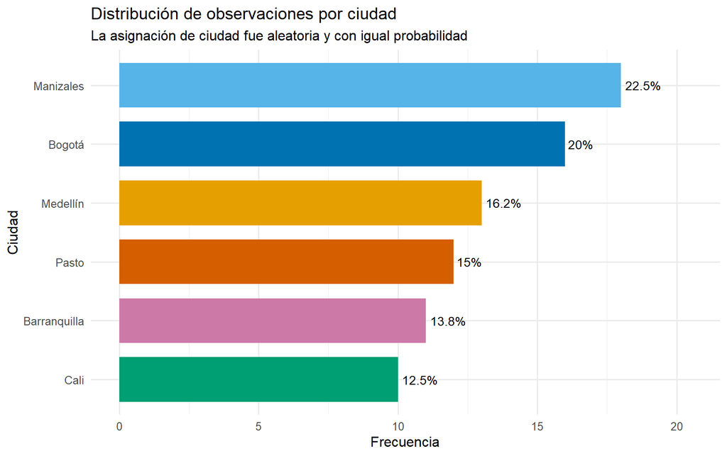

Frecuencia de observaciones por ciudad.

```r
ggplot(frecuencia_ciudad, aes(x = reorder(ciudad, frecuencia), y = frecuencia, fill = ciudad)) + # Ordena las ciudades por frecuencia y asigna un color propio a cada una.
  geom_col(width = 0.76, show.legend = FALSE) + # Dibuja las barras y omite una leyenda redundante porque las ciudades ya aparecen en el eje.
  geom_text(aes(label = paste0(round(porcentaje, 1), "%")), hjust = -0.12, size = 3.7) + # Añade el porcentaje al extremo de cada barra para complementar la comparación visual.
  coord_flip() + # Invierte los ejes y mejora la legibilidad de los nombres de las ciudades.
  scale_fill_manual(values = paleta_ciudades) + # Aplica la paleta definida para las seis ciudades.
  expand_limits(y = max(frecuencia_ciudad$frecuencia) * 1.14) + # Reserva espacio horizontal para que las etiquetas porcentuales no queden cortadas.
  labs(title = "Distribución de observaciones por ciudad", subtitle = "La asignación de ciudad fue aleatoria y con igual probabilidad", x = "Ciudad", y = "Frecuencia") + # Contextualiza el gráfico y evita inferencias poblacionales incorrectas.
  theme_minimal(base_size = 12) # Mantiene el estilo visual de la práctica.
```

### 4.11.1 Análisis conjunto

Las diferencias entre barras son producto del muestreo aleatorio simulado. No representan el tamaño poblacional de las ciudades ni tasas reales de participación. Este ejemplo ayuda a distinguir entre **distribución de la muestra** y **distribución de la población**.

Para una variable categórica, frecuencia y porcentaje son resúmenes naturales. La media no tiene sentido porque las categorías no representan cantidades. El gráfico de barras facilita comparar longitudes sobre una misma escala, razón por la cual se prioriza sobre el gráfico de sectores.

## 4.12 12. Comparación de estatura por ciudad

```r
resumen_ciudad <- encuesta |> # Parte de todas las observaciones de la encuesta.
  group_by(ciudad) |> # Divide la base conceptualmente según la ciudad asignada.
  summarise( # Calcula el mismo conjunto de medidas dentro de cada grupo.
    n = n(), # Cuenta cuántas personas aparecen en cada ciudad.
    media_estatura = mean(estatura), # Calcula la estatura media dentro de cada ciudad.
    mediana_estatura = median(estatura), # Calcula la mediana de estatura de cada grupo.
    sd_estatura = sd(estatura), # Calcula la desviación estándar de estatura dentro de cada ciudad.
    .groups = "drop" # Elimina la agrupación al terminar el resumen.
  ) |> # Envía la tabla de resultados al paso de ordenamiento.
  arrange(desc(media_estatura)) # Ordena las ciudades de mayor a menor estatura media observada.
resumen_ciudad # Muestra la comparación numérica entre los seis grupos.
```

| ciudad | n | media_estatura | mediana_estatura | sd_estatura |
| --- | --- | --- | --- | --- |
| Manizales | 18 | 1.707222 | 1.725 | 0.07939518 |
| Cali | 10 | 1.687000 | 1.690 | 0.10044899 |
| Barranquilla | 11 | 1.680909 | 1.680 | 0.13974652 |
| Medellín | 13 | 1.668462 | 1.660 | 0.06478762 |
| Bogotá | 16 | 1.660000 | 1.660 | 0.10639549 |
| Pasto | 12 | 1.646667 | 1.635 | 0.09939209 |

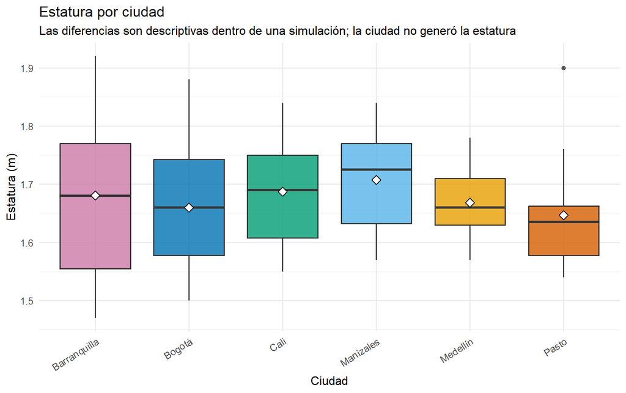

Distribución de estatura por ciudad en la encuesta simulada.

```r
ggplot(encuesta, aes(x = ciudad, y = estatura, fill = ciudad)) + # Inicia un boxplot para comparar la distribución de estatura entre ciudades.
  geom_boxplot(alpha = 0.8, show.legend = FALSE) + # Dibuja las cajas con colores diferenciados y omite una leyenda redundante.
  stat_summary(fun = mean, geom = "point", shape = 23, size = 3, fill = "white", color = "black") + # Superpone la media de cada ciudad como un rombo blanco.
  scale_fill_manual(values = paleta_ciudades) + # Aplica la misma codificación cromática usada en el gráfico de frecuencias.
  labs(title = "Estatura por ciudad", subtitle = "Las diferencias son descriptivas dentro de una simulación; la ciudad no generó la estatura", x = "Ciudad", y = "Estatura (m)") + # Añade un recordatorio explícito sobre el alcance de la comparación.
  theme_minimal(base_size = 12) + # Aplica la presentación general del documento.
  theme(axis.text.x = element_text(angle = 32, hjust = 1)) # Inclina las etiquetas para evitar superposición.
```

### 4.12.1 Análisis conjunto

Ordenar las medias permite localizar rápidamente qué grupos quedaron arriba o abajo en esta muestra, pero el boxplot revela si las distribuciones se solapan ampliamente. Dos grupos pueden tener medias diferentes y, al mismo tiempo, compartir gran parte de sus valores individuales.

La interpretación correcta es descriptiva: “en esta muestra simulada, la media de una ciudad fue mayor”. No es correcto concluir que la ciudad explique la estatura porque el mecanismo generador asignó ciudad independientemente de estatura.

# 5 Parte II. Transferencia a dos bases reales completas

La principal diferencia respecto a la versión anterior es que aquí **el tratamiento de valores faltantes desaparece como objetivo de aprendizaje**. La completitud se verifica una sola vez al inicio de cada reto y, a partir de ahí, el tiempo se concentra en comprender variables, elegir resúmenes y construir interpretaciones.

## 5.1 Protocolo común para una base real completa

Antes de calcular cualquier estadístico:

1. Identifique qué representa una fila.
2. Revise nombres, dimensiones y tipos de variables.
3. Compruebe que la base efectivamente no contiene valores faltantes.
4. Distinga variables cuantitativas, categóricas e identificadores.
5. Formule una pregunta descriptiva antes de elegir el gráfico.
6. Integre medidas numéricas y evidencia visual en la conclusión.

# 6 Reto A. Contaminación atmosférica con `USairpollution`

## 6.1 13. Carga, unidad de análisis y comprobación de completitud

`USairpollution` contiene información de 41 ciudades estadounidenses. El nivel medio anual de dióxido de azufre (`SO2`) funciona como indicador de contaminación, mientras que las demás variables caracterizan temperatura, actividad manufacturera, población, viento y precipitación.

```r
data("USairpollution", package = "HSAUR3") # Carga la base de contaminación directamente desde el paquete HSAUR3 sin adjuntar el paquete al entorno de búsqueda.
ambiente <- USairpollution |> # Toma la base original como punto de partida para crear una copia de trabajo.
  mutate(ciudad = rownames(USairpollution), .before = 1) # Convierte los nombres de fila en una columna explícita de ciudad para facilitar filtros, tablas y gráficos.
total_faltantes_ambiente <- sum(is.na(ambiente)) # Cuenta todos los valores NA de la base completa.
estado_completitud_ambiente <- if (total_faltantes_ambiente == 0) "Base completa" else "Base con datos faltantes" # Registra el estado de completitud sin interrumpir abruptamente la compilación del documento.
names(ambiente) # Muestra los nombres de las variables después de incorporar la ciudad como columna.
```

```
## [1] "ciudad"  "SO2"     "temp"    "manu"    "popul"   "wind"    "precip"
## [8] "predays"
```

```r
dim(ambiente) # Informa el número de ciudades y el número total de columnas de trabajo.
```

```
## [1] 41  8
```

```r
str(ambiente) # Revisa el tipo computacional de cada variable.
```

```
## 'data.frame':    41 obs. of  8 variables:
##  $ ciudad : chr  "Albany" "Albuquerque" "Atlanta" "Baltimore" ...
##  $ SO2    : int  46 11 24 47 11 31 110 23 65 26 ...
##  $ temp   : num  47.6 56.8 61.5 55 47.1 55.2 50.6 54 49.7 51.5 ...
##  $ manu   : int  44 46 368 625 391 35 3344 462 1007 266 ...
##  $ popul  : int  116 244 497 905 463 71 3369 453 751 540 ...
##  $ wind   : num  8.8 8.9 9.1 9.6 12.4 6.5 10.4 7.1 10.9 8.6 ...
##  $ precip : num  33.36 7.77 48.34 41.31 36.11 ...
##  $ predays: int  135 58 115 111 166 148 122 132 155 134 ...
```

```r
glimpse(ambiente) # Presenta una inspección compacta con nombres, tipos y algunos valores.
```

```
## Rows: 41
## Columns: 8
## $ ciudad  <chr> "Albany", "Albuquerque", "Atlanta", "Baltimore", "Buffalo", "C…
## $ SO2     <int> 46, 11, 24, 47, 11, 31, 110, 23, 65, 26, 9, 17, 17, 35, 56, 10…
## $ temp    <dbl> 47.6, 56.8, 61.5, 55.0, 47.1, 55.2, 50.6, 54.0, 49.7, 51.5, 66…
## $ manu    <int> 44, 46, 368, 625, 391, 35, 3344, 462, 1007, 266, 641, 454, 104…
## $ popul   <int> 116, 244, 497, 905, 463, 71, 3369, 453, 751, 540, 844, 515, 20…
## $ wind    <dbl> 8.8, 8.9, 9.1, 9.6, 12.4, 6.5, 10.4, 7.1, 10.9, 8.6, 10.9, 9.0…
## $ precip  <dbl> 33.36, 7.77, 48.34, 41.31, 36.11, 40.75, 34.44, 39.04, 34.99, …
## $ predays <int> 135, 58, 115, 111, 166, 148, 122, 132, 155, 134, 78, 86, 103, …
```

```r
head(ambiente, 6) # Muestra las primeras seis ciudades para interpretar la estructura de una observación.
```

|  | ciudad | SO2 | temp | manu | popul | wind | precip | predays |
| --- | --- | --- | --- | --- | --- | --- | --- | --- |
| Albany | Albany | 46 | 47.6 | 44 | 116 | 8.8 | 33.36 | 135 |
| Albuquerque | Albuquerque | 11 | 56.8 | 46 | 244 | 8.9 | 7.77 | 58 |
| Atlanta | Atlanta | 24 | 61.5 | 368 | 497 | 9.1 | 48.34 | 115 |
| Baltimore | Baltimore | 47 | 55.0 | 625 | 905 | 9.6 | 41.31 | 111 |
| Buffalo | Buffalo | 11 | 47.1 | 391 | 463 | 12.4 | 36.11 | 166 |
| Charleston | Charleston | 31 | 55.2 | 35 | 71 | 6.5 | 40.75 | 148 |

### 6.1.1 Análisis del resultado

La base de trabajo contiene **41 ciudades**, **8 columnas** y **0 datos faltantes**. El diagnóstico de completitud es **Base completa**. La base documentada permite continuar sin procedimientos de imputación: todas las medidas se calculan sobre las mismas 41 unidades estadísticas.

La unidad de análisis es una **ciudad**, no una persona ni una medición diaria. Esto modifica la interpretación: `SO2` es una concentración media anual asociada a cada ciudad, y `temp`, `wind` o `precip` son también resúmenes anuales. Por tanto, una correlación en esta base describe diferencias **entre ciudades** y no variación día a día dentro de una ciudad.

## 6.2 14. Resumen numérico de la contaminación por SO2

```r
resumen_so2 <- ambiente |> # Parte de las 41 ciudades disponibles.
  summarise( # Resume la variable principal de contaminación en una sola fila.
    n_ciudades = n(), # Cuenta el número de ciudades analizadas.
    media = mean(SO2), # Calcula la concentración media de SO2 entre ciudades.
    mediana = median(SO2), # Calcula la mediana de las concentraciones observadas.
    sd = sd(SO2), # Calcula la desviación estándar entre ciudades.
    q1 = quantile(SO2, 0.25), # Calcula el primer cuartil de SO2.
    q3 = quantile(SO2, 0.75), # Calcula el tercer cuartil de SO2.
    IQR = IQR(SO2), # Calcula el rango intercuartílico.
    minimo = min(SO2), # Identifica la menor concentración media anual observada.
    maximo = max(SO2) # Identifica la mayor concentración media anual observada.
  ) # Cierra el resumen estadístico.
resumen_so2 # Imprime la tabla de medidas descriptivas.
```

| n_ciudades | media | mediana | sd | q1 | q3 | IQR | minimo | maximo |
| --- | --- | --- | --- | --- | --- | --- | --- | --- |
| 41 | 30.04878 | 26 | 23.47227 | 13 | 35 | 22 | 8 | 110 |

### 6.2.1 Análisis del resultado

La media de SO2 es aproximadamente **30**, mientras que la mediana es **26 microgramos por metro cúbico**. La razón media/mediana es aproximadamente **1.16**. Si la media queda sensiblemente por encima de la mediana, ello sugiere que algunas ciudades con niveles altos desplazan el centro aritmético hacia arriba.

El 50 % central de las ciudades se encuentra entre **13** y **35**, con un IQR de **22**. Esta combinación de mediana e IQR es particularmente útil si el histograma revela asimetría o ciudades con concentraciones excepcionalmente altas.

## 6.3 15. Distribución del SO2

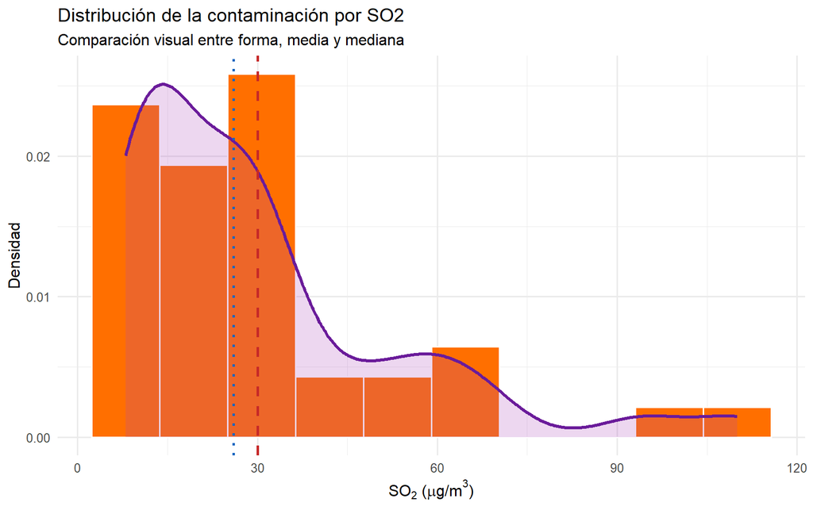

Distribución del contenido medio anual de SO2 entre ciudades.

```r
ggplot(ambiente, aes(x = SO2)) + # Inicia un gráfico univariado de la concentración de dióxido de azufre.
  geom_histogram(aes(y = after_stat(density)), bins = 10, fill = "#FF6F00", color = "white", linewidth = 0.7) + # Dibuja un histograma naranja intenso en escala de densidad.
  geom_density(color = "#6A1B9A", fill = "#AB47BC", alpha = 0.22, linewidth = 1.2) + # Superpone una densidad morada para destacar la forma global de la distribución.
  geom_vline(xintercept = resumen_so2$media, color = "#C62828", linetype = "dashed", linewidth = 1) + # Marca la media con una línea roja discontinua.
  geom_vline(xintercept = resumen_so2$mediana, color = "#1565C0", linetype = "dotted", linewidth = 1) + # Marca la mediana con una línea azul punteada.
  labs(title = "Distribución de la contaminación por SO2", subtitle = "Comparación visual entre forma, media y mediana", x = expression(paste(SO[2], " (", mu, "g/m"^3, ")")), y = "Densidad") + # Añade título, propósito y unidad física del contaminante.
  theme_minimal(base_size = 12) # Aplica un estilo limpio que enfatiza los elementos estadísticos.
```

### 6.3.1 Análisis del gráfico

Este gráfico permite evaluar si la media representa bien una ciudad “típica”. Una cola derecha pronunciada indicaría que pocas ciudades con contaminación elevada tienen gran influencia sobre el promedio. En ese escenario, mediana e IQR ofrecen una descripción del centro y dispersión menos condicionada por esos extremos.

La comparación entre las dos líneas verticales debe concordar con la forma del histograma: una separación visible entre media y mediana es una señal gráfica de asimetría. El objetivo del análisis no es escoger una única medida “correcta”, sino justificar qué medida comunica mejor el aspecto que interesa describir.

## 6.4 16. Actividad manufacturera y niveles de SO2

Para transformar una variable cuantitativa en un contraste didáctico sencillo, se divide la actividad manufacturera respecto a su mediana. Esta categorización no pretende establecer un umbral científico; se utiliza únicamente para practicar comparación de distribuciones entre grupos.

```r
mediana_manu <- median(ambiente$manu) # Calcula la mediana del número de empresas manufactureras para usarla como punto de corte descriptivo.
ambiente <- ambiente |> # Toma la base ambiental completa.
  mutate(grupo_industrial = if_else(manu >= mediana_manu, "Actividad industrial alta", "Actividad industrial baja")) # Clasifica las ciudades según estén por encima o por debajo de la mediana manufacturera.
resumen_industrial <- ambiente |> # Parte de la base que ya contiene el grupo industrial.
  group_by(grupo_industrial) |> # Separa las ciudades en los dos grupos descriptivos.
  summarise(n = n(), media_SO2 = mean(SO2), mediana_SO2 = median(SO2), sd_SO2 = sd(SO2), .groups = "drop") # Calcula tamaño, media, mediana y dispersión de SO2 dentro de cada grupo.
resumen_industrial # Muestra la comparación numérica entre los dos grupos de ciudades.
```

| grupo_industrial | n | media_SO2 | mediana_SO2 | sd_SO2 |
| --- | --- | --- | --- | --- |
| Actividad industrial alta | 21 | 35.71429 | 29.0 | 25.81306 |
| Actividad industrial baja | 20 | 24.10000 | 17.5 | 19.64126 |

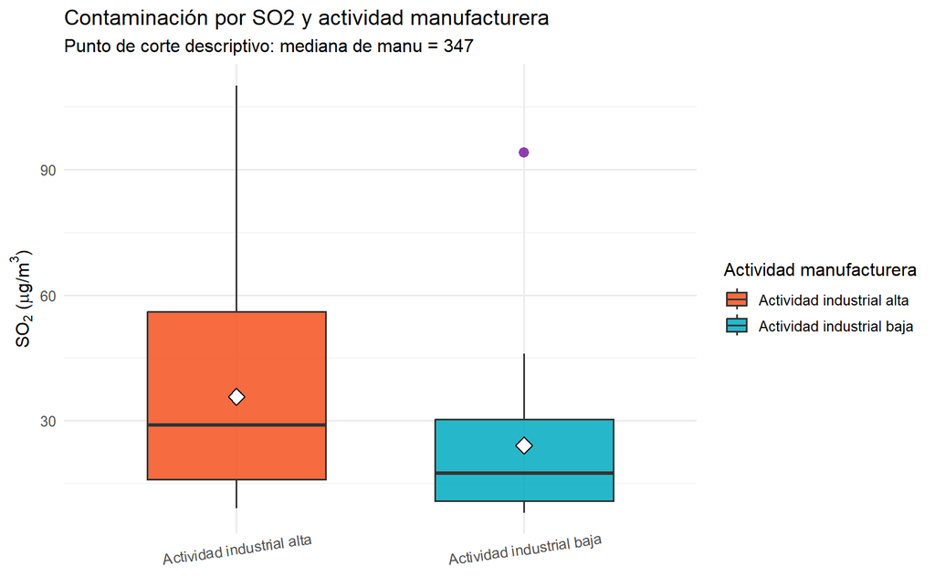

SO2 según nivel descriptivo de actividad manufacturera.

```r
ggplot(ambiente, aes(x = grupo_industrial, y = SO2, fill = grupo_industrial)) + # Inicia un boxplot de SO2 según el grupo manufacturero construido.
  geom_boxplot(alpha = 0.85, width = 0.62, outlier.color = "#7B1FA2", outlier.size = 2.8) + # Dibuja las distribuciones y resalta posibles observaciones extremas.
  stat_summary(fun = mean, geom = "point", shape = 23, size = 3.8, fill = "white", color = "black") + # Superpone la media de cada grupo como rombo blanco.
  scale_fill_manual(values = c("Actividad industrial baja" = "#00ACC1", "Actividad industrial alta" = "#F4511E"), name = "Actividad manufacturera") + # Asigna azul turquesa y naranja a los grupos y conserva una leyenda explícita.
  labs(title = "Contaminación por SO2 y actividad manufacturera", subtitle = paste0("Punto de corte descriptivo: mediana de manu = ", mediana_manu), x = NULL, y = expression(paste(SO[2], " (", mu, "g/m"^3, ")"))) + # Explica que el umbral procede de la mediana y no de una norma externa.
  theme_minimal(base_size = 12) + # Aplica la estética general.
  theme(axis.text.x = element_text(angle = 8, hjust = 0.5)) # Ajusta ligeramente las etiquetas para mejorar su lectura.
```

### 6.4.1 Análisis conjunto

La tabla permite comparar centro y dispersión, mientras el boxplot muestra solapamiento y valores extremos. Si el grupo de mayor actividad manufacturera presenta una media o mediana de SO2 mayor, el resultado constituye una **asociación descriptiva entre ciudades**, no una demostración causal.

El punto de corte es artificial y se introdujo para simplificar la comparación. En un estudio formal sería preferible conservar la variable `manu` en su escala cuantitativa y estudiar directamente su relación con `SO2`, como se hace a continuación.

## 6.5 17. Relación cuantitativa entre manufactura y SO2

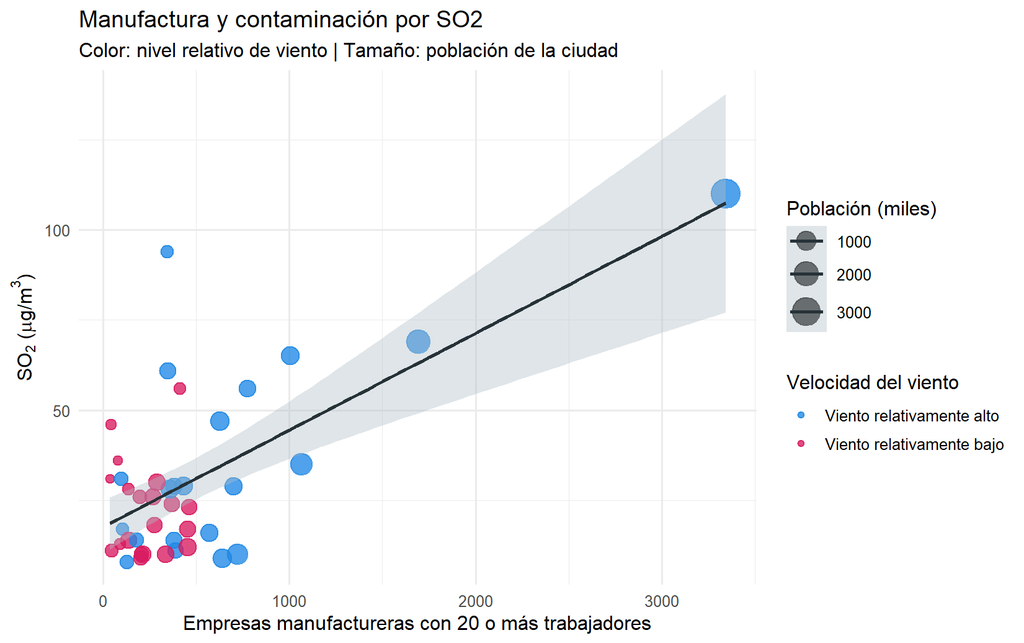

Relación entre actividad manufacturera y SO2; el color representa el nivel de viento.

```r
mediana_viento <- median(ambiente$wind) # Calcula la mediana de la velocidad del viento para crear dos categorías visuales interpretables.
ambiente <- ambiente |> # Parte de la base ambiental con el grupo industrial ya creado.
  mutate(nivel_viento = if_else(wind >= mediana_viento, "Viento relativamente alto", "Viento relativamente bajo")) # Clasifica las ciudades según la velocidad del viento respecto a su mediana.
ggplot(ambiente, aes(x = manu, y = SO2, color = nivel_viento, size = popul)) + # Ubica manufactura y SO2 en los ejes y utiliza color y tamaño para añadir viento y población.
  geom_point(alpha = 0.78) + # Dibuja las ciudades con transparencia moderada para evitar ocultar superposiciones.
  geom_smooth(aes(group = 1), method = "lm", se = TRUE, color = "#263238", fill = "#B0BEC5", linewidth = 1) + # Añade una tendencia lineal global independiente de las categorías de color.
  scale_color_manual(values = c("Viento relativamente bajo" = "#D81B60", "Viento relativamente alto" = "#1E88E5"), name = "Velocidad del viento") + # Aplica dos colores intensos y genera una leyenda que explica su significado.
  scale_size_continuous(name = "Población (miles)", range = c(2.2, 8)) + # Ajusta el tamaño de los puntos según población y conserva la leyenda de escala.
  labs(title = "Manufactura y contaminación por SO2", subtitle = "Color: nivel relativo de viento | Tamaño: población de la ciudad", x = "Empresas manufactureras con 20 o más trabajadores", y = expression(paste(SO[2], " (", mu, "g/m"^3, ")"))) + # Explica cómo leer las cuatro dimensiones incorporadas al gráfico.
  theme_minimal(base_size = 12) # Aplica una presentación clara.
```

### 6.5.1 Análisis del gráfico

La nube de puntos conserva toda la información cuantitativa de `manu`, a diferencia de la dicotomización anterior. La pendiente visual resume la dirección global, mientras la dispersión alrededor de la línea informa cuánto varía el SO2 entre ciudades con niveles manufactureros similares.

El color permite inspeccionar si las ciudades con vientos relativamente altos o bajos ocupan zonas diferentes de la nube. El tamaño recuerda que las ciudades también difieren en población. Este gráfico ilustra un principio importante: una asociación bivariada puede estar inmersa en una estructura multivariable; por eso una explicación causal no puede basarse exclusivamente en una correlación simple.

## 6.6 18. Correlaciones de SO2 con las variables ambientales

```r
variables_aire <- ambiente |> # Parte de la base ambiental completa.
  select(SO2, temp, manu, popul, wind, precip, predays) # Conserva únicamente las siete variables cuantitativas originales.
matriz_cor_aire <- cor(variables_aire) # Calcula la matriz de correlaciones de Pearson sin opciones para NA porque la base es completa.
nombres_variables_cor <- colnames(matriz_cor_aire) # Extrae correctamente los nombres de las columnas de la matriz; en una matriz se usa colnames() y no names().
valores_cor_so2 <- as.numeric(matriz_cor_aire["SO2", nombres_variables_cor]) # Extrae las correlaciones de SO2 siguiendo exactamente el mismo orden de los nombres de columna.
stopifnot(length(nombres_variables_cor) == length(valores_cor_so2)) # Verifica preventivamente que nombres y valores tengan la misma longitud antes de construir la tabla.
correlaciones_so2 <- data.frame(variable = nombres_variables_cor, correlacion = valores_cor_so2) |> # Construye una tabla válida con una fila por variable y su correlación con SO2.
  filter(variable != "SO2") |> # Elimina la autocorrelación perfecta de SO2 consigo mismo.
  arrange(desc(abs(correlacion))) # Ordena las variables desde la asociación lineal de mayor magnitud absoluta hasta la menor.
round(matriz_cor_aire, 3) # Muestra la matriz completa redondeada a tres decimales.
```

```
##            SO2   temp   manu  popul   wind precip predays
## SO2      1.000 -0.434  0.645  0.494  0.095  0.054   0.370
## temp    -0.434  1.000 -0.190 -0.063 -0.350  0.386  -0.430
## manu     0.645 -0.190  1.000  0.955  0.238 -0.032   0.132
## popul    0.494 -0.063  0.955  1.000  0.213 -0.026   0.042
## wind     0.095 -0.350  0.238  0.213  1.000 -0.013   0.164
## precip   0.054  0.386 -0.032 -0.026 -0.013  1.000   0.496
## predays  0.370 -0.430  0.132  0.042  0.164  0.496   1.000
```

```r
correlaciones_so2 # Muestra el ranking de asociaciones lineales con SO2.
```

| variable | correlacion |
| --- | --- |
| manu | 0.64476873 |
| popul | 0.49377958 |
| temp | -0.43360020 |
| predays | 0.36956363 |
| wind | 0.09469045 |
| precip | 0.05429434 |

### 6.6.1 Análisis del resultado

**Nota computacional.** Una matriz en R almacena sus etiquetas por dimensión mediante `rownames()` y `colnames()`. La función `names()` no devuelve los nombres de sus columnas y, aplicada a esta matriz, produce un vector de longitud cero. Por eso el bloque utiliza explícitamente `colnames(matriz_cor_aire)` y comprueba que la cantidad de nombres coincida con la cantidad de correlaciones antes de construir el `data.frame`. Esta verificación evita que el proceso de *Knit* se interrumpa por longitudes incompatibles.

La tabla ordenada permite identificar qué variables presentan mayor asociación lineal con `SO2` dentro de estas 41 ciudades. El valor de mayor magnitud absoluta es **0.64**, correspondiente a **manu**. El signo indica la dirección de la asociación: positivo significa que ambas variables tienden a crecer conjuntamente; negativo, que valores altos de una tienden a asociarse con valores bajos de la otra.

La correlación no considera por sí sola relaciones no lineales, valores influyentes ni confusión entre variables. Por ello, la tabla debe utilizarse como **mapa exploratorio** que orienta qué diagramas de dispersión conviene estudiar, no como una explicación definitiva de la contaminación.

## 6.7 19. Ciudades con los niveles más altos de SO2

```r
top_so2 <- ambiente |> # Parte de las 41 ciudades de la base.
  arrange(desc(SO2)) |> # Ordena las ciudades de mayor a menor concentración de SO2.
  slice_head(n = 10) # Conserva las diez ciudades con mayores niveles observados.
top_so2 |> select(ciudad, SO2, manu, popul, wind) # Muestra las variables más relevantes para contextualizar las diez ciudades destacadas.
```

|  | ciudad | SO2 | manu | popul | wind |
| --- | --- | --- | --- | --- | --- |
| Chicago | Chicago | 110 | 3344 | 3369 | 10.4 |
| Providence | Providence | 94 | 343 | 179 | 10.6 |
| Philadelphia | Philadelphia | 69 | 1692 | 1950 | 9.6 |
| Cleveland | Cleveland | 65 | 1007 | 751 | 10.9 |
| Pittsburgh | Pittsburgh | 61 | 347 | 520 | 9.4 |
| Hartford | Hartford | 56 | 412 | 158 | 9.0 |
| St. Louis | St. Louis | 56 | 775 | 622 | 9.5 |
| Baltimore | Baltimore | 47 | 625 | 905 | 9.6 |
| Albany | Albany | 46 | 44 | 116 | 8.8 |
| Wilmington | Wilmington | 36 | 80 | 80 | 9.0 |

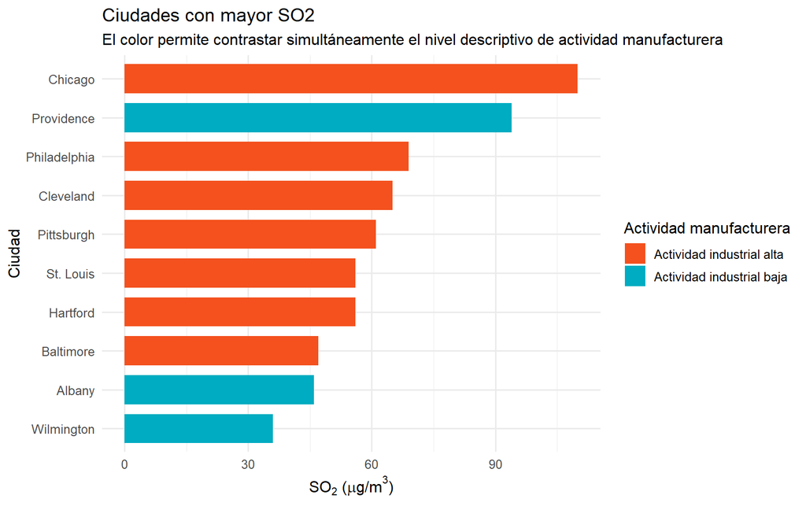

Diez ciudades con mayor concentración media anual de SO2.

```r
ggplot(top_so2, aes(x = reorder(ciudad, SO2), y = SO2, fill = grupo_industrial)) + # Ordena las diez ciudades por SO2 y utiliza el grupo industrial como codificación de color.
  geom_col(width = 0.75) + # Dibuja una barra por ciudad con altura proporcional a su concentración de SO2.
  coord_flip() + # Invierte los ejes para que los nombres de ciudades puedan leerse con claridad.
  scale_fill_manual(values = c("Actividad industrial baja" = "#00ACC1", "Actividad industrial alta" = "#F4511E"), name = "Actividad manufacturera") + # Mantiene la misma paleta del boxplot y conserva la leyenda porque el color añade una segunda dimensión.
  labs(title = "Ciudades con mayor SO2", subtitle = "El color permite contrastar simultáneamente el nivel descriptivo de actividad manufacturera", x = "Ciudad", y = expression(paste(SO[2], " (", mu, "g/m"^3, ")"))) + # Explica el propósito del color y las unidades del eje.
  theme_minimal(base_size = 12) # Mantiene la coherencia estética de la práctica.
```

### 6.7.1 Análisis conjunto

El ranking localiza observaciones de interés sin convertirlas automáticamente en “errores” o “outliers”. Una ciudad con SO2 alto puede ser un caso real e informativo. El paso apropiado es contextualizarla mediante manufactura, población, viento y otras variables.

El color del gráfico facilita comprobar si las ciudades de mayor contaminación pertenecen predominantemente al grupo de actividad manufacturera alta. Incluso si aparece un patrón claro, sigue siendo una descripción de asociación. Una interpretación rigurosa distingue siempre entre **lo que muestran los datos** y **la explicación que requeriría un diseño analítico adicional**.

# 7 Nota técnica sobre la corrección de esta versión

La versión anterior utilizaba `CHFLS` y detenía la compilación mediante `stopifnot(total_faltantes_salud == 0)`. En el entorno de RStudio mostrado durante la prueba, esa condición resultó falsa y el *Knit* se interrumpió. Esta versión no oculta el problema ni elimina observaciones silenciosamente: **sustituye la base de salud por `respiratory`**, cuya documentación oficial declara de forma explícita ausencia de datos faltantes en respuesta y covariables. Además, las verificaciones de completitud se registran como información descriptiva y no como aserciones fatales, por lo que el documento no se detiene únicamente por una comprobación diagnóstica.

# 8 Reto B. Salud clínica con `HSAUR3::respiratory`

## 8.1 20. Carga, unidad de análisis y completitud

Para evitar el problema observado con `CHFLS`, esta versión utiliza la base **`respiratory`** del mismo paquete `HSAUR3`. La documentación oficial describe un ensayo clínico multicéntrico en el que 111 pacientes fueron asignados a tratamiento activo o placebo y evaluados en los meses 0, 1, 2, 3 y 4. La documentación señala explícitamente que **no existen datos faltantes en la respuesta ni en las covariables**.

Esta base es especialmente útil para una práctica de estadística descriptiva porque añade una dificultad conceptual importante sin introducir limpieza de datos: **555 filas no significan 555 pacientes**. Cada fila corresponde a una observación paciente-momento; por tanto, la unidad de análisis depende de la pregunta que se quiera responder.

```r
data("respiratory", package = "HSAUR3") # Carga la base respiratory desde HSAUR3 sin adjuntar el paquete al entorno de trabajo.
salud <- respiratory # Crea una copia de trabajo con un nombre corto y semánticamente claro.
total_faltantes_salud <- sum(is.na(salud)) # Cuenta todos los valores faltantes presentes en la base cargada.
estado_completitud_salud <- if (total_faltantes_salud == 0) "Base completa" else "Base con datos faltantes" # Registra el estado de completitud sin detener la compilación con una aserción fatal.
numero_pacientes <- dplyr::n_distinct(salud$subject) # Cuenta cuántos pacientes distintos aparecen en la estructura longitudinal.
numero_registros <- nrow(salud) # Cuenta cuántas filas paciente-momento contiene la base completa.
meses_observados <- sort(unique(as.numeric(as.character(salud$month)))) # Recupera y ordena los cinco momentos de observación en una escala numérica legible.
names(salud) # Muestra los nombres exactos de las siete variables disponibles.
```

```
## [1] "centre"    "treatment" "gender"    "age"       "status"    "month"
## [7] "subject"
```

```r
dim(salud) # Informa el número de registros y de variables de la base.
```

```
## [1] 555   7
```

```r
str(salud) # Revisa el tipo computacional de cada variable antes de resumirla.
```

```
## 'data.frame':    555 obs. of  7 variables:
##  $ centre   : Factor w/ 2 levels "1","2": 1 1 1 1 1 1 1 1 1 1 ...
##  $ treatment: Factor w/ 2 levels "placebo","treatment": 1 1 1 1 1 1 1 1 1 1 ...
##  $ gender   : Factor w/ 2 levels "female","male": 1 1 1 1 1 1 1 1 1 1 ...
##  $ age      : num  46 46 46 46 46 28 28 28 28 28 ...
##  $ status   : Factor w/ 2 levels "poor","good": 1 1 1 1 1 1 1 1 1 1 ...
##  $ month    : Ord.factor w/ 5 levels "0"<"1"<"2"<"3"<..: 1 2 3 4 5 1 2 3 4 5 ...
##  $ subject  : Factor w/ 111 levels "1","2","3","4",..: 1 1 1 1 1 2 2 2 2 2 ...
```

```r
glimpse(salud) # Presenta una lectura compacta de tipos y primeros valores mediante dplyr.
```

```
## Rows: 555
## Columns: 7
## $ centre    <fct> 1, 1, 1, 1, 1, 1, 1, 1, 1, 1, 1, 1, 1, 1, 1, 1, 1, 1, 1, 1, …
## $ treatment <fct> placebo, placebo, placebo, placebo, placebo, placebo, placeb…
## $ gender    <fct> female, female, female, female, female, female, female, fema…
## $ age       <dbl> 46, 46, 46, 46, 46, 28, 28, 28, 28, 28, 23, 23, 23, 23, 23, …
## $ status    <fct> poor, poor, poor, poor, poor, poor, poor, poor, poor, poor, …
## $ month     <ord> 0, 1, 2, 3, 4, 0, 1, 2, 3, 4, 0, 1, 2, 3, 4, 0, 1, 2, 3, 4, …
## $ subject   <fct> 1, 1, 1, 1, 1, 2, 2, 2, 2, 2, 3, 3, 3, 3, 3, 4, 4, 4, 4, 4, …
```

```r
head(salud, 8) # Muestra ocho registros para observar que un mismo sujeto reaparece en diferentes meses.
```

|  | centre | treatment | gender | age | status | month | subject |
| --- | --- | --- | --- | --- | --- | --- | --- |
| 1 | 1 | placebo | female | 46 | poor | 0 | 1 |
| 112 | 1 | placebo | female | 46 | poor | 1 | 1 |
| 223 | 1 | placebo | female | 46 | poor | 2 | 1 |
| 334 | 1 | placebo | female | 46 | poor | 3 | 1 |
| 445 | 1 | placebo | female | 46 | poor | 4 | 1 |
| 2 | 1 | placebo | female | 28 | poor | 0 | 2 |
| 113 | 1 | placebo | female | 28 | poor | 1 | 2 |
| 224 | 1 | placebo | female | 28 | poor | 2 | 2 |

### 8.1.1 Análisis del resultado

La base contiene **555 registros**, correspondientes a **111 pacientes distintos**, observados en los meses **0, 1, 2, 3, 4**. El conteo total de valores faltantes es **0**, por lo que el diagnóstico es **Base completa**.

La diferencia entre *fila* y *paciente* es crucial. Si calculáramos la edad media utilizando las 555 filas, cada paciente aparecería cinco veces y el resultado sería numéricamente el mismo solo porque la edad permanece constante durante el seguimiento. En otras variables, como `status`, la repetición es precisamente la información de interés. Por ello, el análisis debe decidir primero si la pregunta se formula a nivel de **paciente** o a nivel de **visita**.

`status`, `treatment`, `gender` y `centre` son variables categóricas. `age` es cuantitativa. `month` representa tiempo discreto de seguimiento y `subject` es un identificador; aunque ambos puedan almacenarse con códigos numéricos o factores, no deben interpretarse como variables cuantitativas intercambiables con la edad.

## 8.2 21. Construcción de una tabla basal: una fila por paciente

Para describir las características iniciales de los pacientes se utiliza únicamente el mes 0. Así se evita contar cinco veces a la misma persona al resumir edad, género o asignación de tratamiento.

```r
salud_baseline <- salud |> # Parte de la estructura longitudinal con cinco registros por paciente.
  filter(as.character(month) == "0") # Conserva únicamente la medición basal correspondiente al mes cero.
pacientes_baseline <- dplyr::n_distinct(salud_baseline$subject) # Cuenta el número de sujetos únicos presentes en la visita basal.
registros_baseline <- nrow(salud_baseline) # Cuenta las filas de la tabla basal para verificar que exista una observación por paciente.
verificacion_unicidad <- pacientes_baseline == registros_baseline # Comprueba lógicamente si cada paciente aparece exactamente una vez en la tabla basal.
resumen_baseline <- salud_baseline |> # Parte de una fila por paciente en el momento inicial.
  group_by(treatment) |> # Separa a los pacientes según el brazo asignado del ensayo.
  summarise( # Calcula medidas descriptivas iniciales dentro de cada grupo.
    n = n(), # Cuenta cuántos pacientes pertenecen a cada brazo en el mes cero.
    edad_media = mean(age), # Calcula la edad media inicial por grupo de tratamiento.
    edad_mediana = median(age), # Calcula la edad mediana inicial por grupo.
    edad_sd = sd(age), # Calcula la desviación estándar de la edad dentro de cada brazo.
    porcentaje_mujeres = 100 * mean(gender == "female"), # Calcula el porcentaje de mujeres en cada grupo de tratamiento.
    porcentaje_estado_bueno = 100 * mean(status == "good"), # Calcula el porcentaje con estado respiratorio bueno en la línea basal.
    .groups = "drop" # Elimina la agrupación al terminar la tabla descriptiva.
  ) # Cierra el resumen basal.
resumen_baseline # Muestra la comparación inicial entre los dos grupos.
```

| treatment | n | edad_media | edad_mediana | edad_sd | porcentaje_mujeres | porcentaje_estado_bueno |
| --- | --- | --- | --- | --- | --- | --- |
| placebo | 57 | 33.64912 | 35 | 13.44764 | 70.17544 | 45.61404 |
| treatment | 54 | 32.88889 | 30 | 13.98337 | 88.88889 | 44.44444 |

### 8.2.1 Análisis del resultado

La tabla basal contiene **111 filas** y **111 pacientes distintos**; por tanto, la verificación de una observación por paciente es **TRUE**. Esta comprobación es más importante que cualquier promedio: establece que el resumen inicial no está duplicando sujetos.

La comparación entre tratamiento y placebo no pretende probar todavía equivalencia estadística ni eficacia. Su función descriptiva es examinar si ambos grupos parten de perfiles razonablemente comparables en edad, composición por género y estado respiratorio inicial. Diferencias pequeñas pueden aparecer por variación aleatoria aun en un ensayo aleatorizado; no deben sobrerreaccionarse con conclusiones causales a partir de una tabla descriptiva.

## 8.3 22. Distribución de la edad en la línea basal

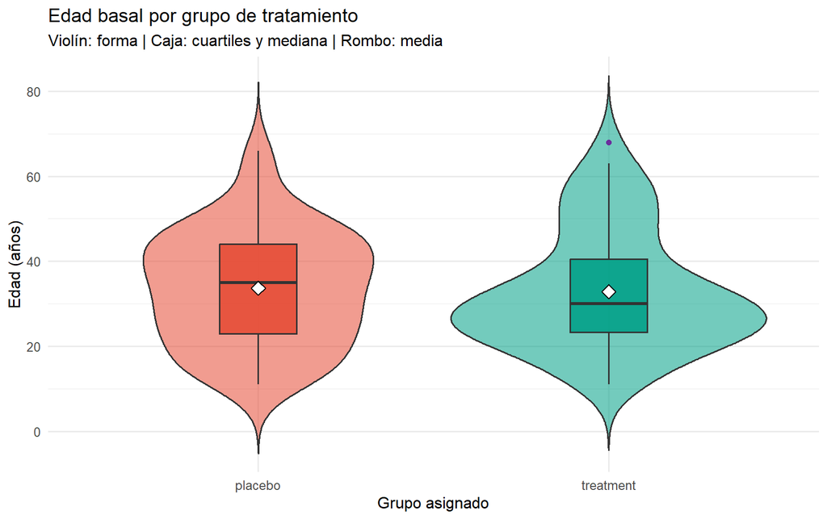

Distribución de la edad basal según grupo de tratamiento.

```r
ggplot(salud_baseline, aes(x = treatment, y = age, fill = treatment)) + # Inicia una comparación de la distribución de edad entre los dos brazos del ensayo.
  geom_violin(alpha = 0.55, trim = FALSE, show.legend = FALSE) + # Muestra la forma aproximada de la distribución dentro de cada grupo sin añadir una leyenda redundante.
  geom_boxplot(width = 0.22, alpha = 0.88, outlier.color = "#6A1B9A", show.legend = FALSE) + # Superpone mediana, cuartiles y posibles valores extremos sobre cada violín.
  stat_summary(fun = mean, geom = "point", shape = 23, size = 3.6, fill = "white", color = "black") + # Añade la edad media de cada grupo como rombo blanco para compararla con la mediana.
  scale_fill_manual(values = paleta_tratamiento) + # Aplica colores contrastantes y consistentes a placebo y tratamiento.
  labs(title = "Edad basal por grupo de tratamiento", subtitle = "Violín: forma | Caja: cuartiles y mediana | Rombo: media", x = "Grupo asignado", y = "Edad (años)") + # Explica cómo leer las tres capas estadísticas del gráfico.
  theme_minimal(base_size = 12) # Aplica una presentación clara y consistente con el resto de la práctica.
```

### 8.3.1 Análisis del gráfico

El gráfico integra tres niveles de información. El **violín** permite comparar la forma global de las distribuciones; la **caja** hace visibles mediana e IQR; y el **rombo blanco** ubica la media. Si media y mediana están próximas dentro de cada brazo, la edad no parece fuertemente asimétrica. Si las cajas se solapan ampliamente, la diferencia entre grupos es pequeña en comparación con la variabilidad interna.

Esta visualización es preferible a mostrar únicamente dos medias porque permite distinguir entre una diferencia de centro y una diferencia en la forma o dispersión de las edades. En una práctica descriptiva, esa lectura estructural es más informativa que declarar simplemente cuál grupo tiene el promedio mayor.

## 8.4 23. Evolución descriptiva del estado respiratorio

Para estudiar el seguimiento sí necesitamos conservar las cinco visitas de cada paciente. Se calcula, dentro de cada combinación de mes y tratamiento, el porcentaje de registros clasificados como `good`.

```r
estado_tiempo <- salud |> # Parte de los 555 registros longitudinales.
  mutate(mes_num = as.numeric(as.character(month))) |> # Convierte el mes a una escala numérica explícita para facilitar el orden temporal de los gráficos.
  count(treatment, mes_num, status, name = "frecuencia") |> # Cuenta registros según tratamiento, mes y estado respiratorio.
  group_by(treatment, mes_num) |> # Define como denominador cada combinación de tratamiento y momento de seguimiento.
  mutate(porcentaje = 100 * frecuencia / sum(frecuencia)) |> # Convierte los conteos en porcentajes comparables dentro de cada grupo y mes.
  ungroup() # Elimina la agrupación después de calcular los porcentajes.
estado_bueno <- estado_tiempo |> # Parte de la tabla porcentual completa.
  filter(status == "good") # Conserva únicamente el porcentaje de registros con estado respiratorio bueno.
estado_bueno # Muestra la trayectoria porcentual que se representará gráficamente.
```

| treatment | mes_num | status | frecuencia | porcentaje |
| --- | --- | --- | --- | --- |
| placebo | 0 | good | 26 | 45.61404 |
| placebo | 1 | good | 28 | 49.12281 |
| placebo | 2 | good | 22 | 38.59649 |
| placebo | 3 | good | 26 | 45.61404 |
| placebo | 4 | good | 25 | 43.85965 |
| treatment | 0 | good | 24 | 44.44444 |
| treatment | 1 | good | 37 | 68.51852 |
| treatment | 2 | good | 38 | 70.37037 |
| treatment | 3 | good | 39 | 72.22222 |
| treatment | 4 | good | 34 | 62.96296 |

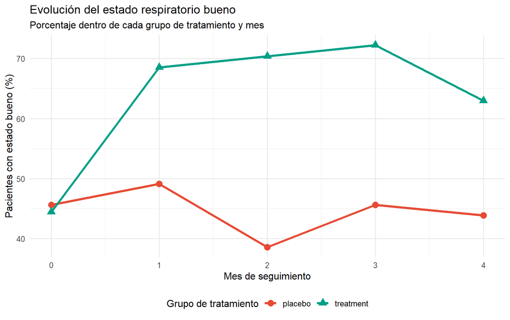

Porcentaje de estado respiratorio bueno a lo largo del seguimiento.

```r
ggplot(estado_bueno, aes(x = mes_num, y = porcentaje, color = treatment, group = treatment, shape = treatment)) + # Inicia una trayectoria temporal distinta para cada brazo del ensayo.
  geom_line(linewidth = 1.25) + # Conecta los porcentajes sucesivos para facilitar la lectura del cambio a través del tiempo.
  geom_point(size = 3.4) + # Marca cada momento observado y evita que la línea sugiera datos continuos no medidos.
  scale_color_manual(values = paleta_tratamiento, name = "Grupo de tratamiento") + # Asigna colores llamativos y conserva la leyenda porque el color identifica una dimensión esencial.
  scale_shape_manual(values = c("placebo" = 16, "treatment" = 17), name = "Grupo de tratamiento") + # Añade una segunda codificación visual que mejora accesibilidad y lectura en impresión.
  scale_x_continuous(breaks = meses_observados) + # Muestra exclusivamente los cinco meses efectivamente observados.
  labs(title = "Evolución del estado respiratorio bueno", subtitle = "Porcentaje dentro de cada grupo de tratamiento y mes", x = "Mes de seguimiento", y = "Pacientes con estado bueno (%)") + # Explicita el denominador y el significado de la trayectoria.
  theme_minimal(base_size = 12) + # Aplica una estética académica limpia.
  theme(legend.position = "bottom") # Coloca la leyenda debajo para no competir visualmente con las líneas.
```

### 8.4.1 Análisis conjunto

Este gráfico responde una pregunta distinta del boxplot de edad: ya no describe quiénes eran los pacientes inicialmente, sino **cómo cambia la composición del estado respiratorio a través de las visitas**. La altura de cada punto es un porcentaje dentro del grupo y mes correspondiente; por ello, se pueden comparar trayectorias aunque los grupos tengan tamaños ligeramente diferentes.

Si las líneas se separan después del mes 0, la figura sugiere una evolución descriptiva diferente entre los grupos. Sin embargo, en esta práctica no se realiza una prueba de hipótesis ni un modelo longitudinal. Además, las cinco observaciones de un mismo paciente no son independientes entre sí. La gráfica describe el patrón observado; la evaluación formal de un efecto de tratamiento requeriría métodos que tengan en cuenta la estructura repetida.

## 8.5 24. Resumen a nivel de paciente: número de visitas con estado bueno

Una forma sencilla de volver de la estructura longitudinal a una tabla de una fila por paciente consiste en contar cuántas de las cinco visitas fueron registradas con estado respiratorio `good`.

```r
salud_sujeto <- salud |> # Parte de todos los registros paciente-momento.
  group_by(subject) |> # Agrupa las cinco visitas correspondientes a cada paciente.
  summarise( # Reduce el seguimiento completo a una sola fila por sujeto.
    treatment = first(treatment), # Conserva el grupo de tratamiento, que es constante para cada paciente.
    gender = first(gender), # Conserva el género del paciente, también constante durante el seguimiento.
    age = first(age), # Conserva la edad registrada para el paciente.
    visitas_totales = n(), # Cuenta cuántas observaciones de seguimiento tiene cada sujeto.
    visitas_buenas = sum(status == "good"), # Cuenta en cuántas visitas el estado respiratorio fue clasificado como bueno.
    porcentaje_visitas_buenas = 100 * visitas_buenas / visitas_totales, # Expresa el número de visitas buenas como porcentaje del seguimiento individual.
    .groups = "drop" # Elimina la agrupación al producir la tabla paciente-nivel.
  ) # Cierra el resumen por sujeto.
resumen_visitas_tratamiento <- salud_sujeto |> # Parte de una fila por paciente.
  group_by(treatment) |> # Divide los sujetos según el brazo asignado.
  summarise(n = n(), media_visitas_buenas = mean(visitas_buenas), mediana_visitas_buenas = median(visitas_buenas), sd_visitas_buenas = sd(visitas_buenas), .groups = "drop") # Resume centro y dispersión del número de visitas buenas por tratamiento.
resumen_visitas_tratamiento # Muestra la comparación numérica de la trayectoria resumida por paciente.
```

| treatment | n | media_visitas_buenas | mediana_visitas_buenas | sd_visitas_buenas |
| --- | --- | --- | --- | --- |
| placebo | 57 | 2.228070 | 2 | 1.908791 |
| treatment | 54 | 3.185185 | 4 | 1.812681 |

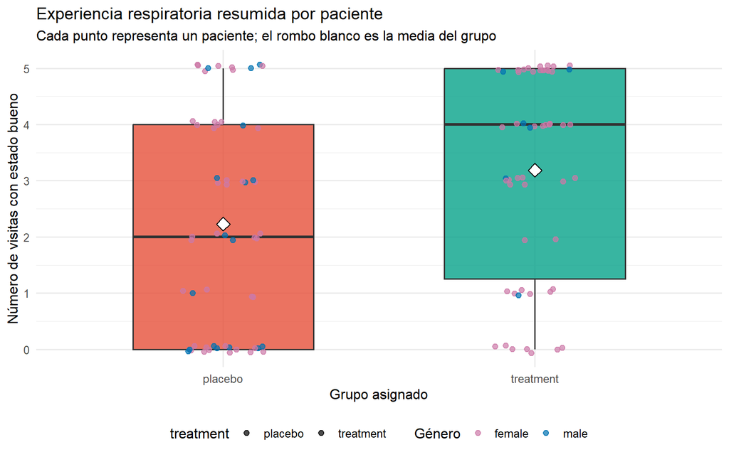

Número de visitas con estado respiratorio bueno por paciente.

```r
ggplot(salud_sujeto, aes(x = treatment, y = visitas_buenas, fill = treatment)) + # Inicia la comparación del número de visitas buenas entre los dos brazos.
  geom_boxplot(alpha = 0.78, width = 0.58, show.legend = FALSE, outlier.shape = NA) + # Resume mediana e IQR y evita duplicar como outliers los puntos que se mostrarán individualmente.
  geom_jitter(aes(color = gender), width = 0.13, height = 0.07, alpha = 0.70, size = 2.0) + # Añade cada paciente y usa color para mostrar simultáneamente su género.
  stat_summary(fun = mean, geom = "point", shape = 23, size = 4, fill = "white", color = "black") + # Superpone la media de visitas buenas como rombo blanco.
  scale_fill_manual(values = paleta_tratamiento) + # Mantiene la codificación cromática de los grupos aunque la leyenda de relleno se omita por redundancia con el eje.
  scale_color_manual(values = paleta_genero_resp, name = "Género") + # Utiliza colores diferenciables para el género y conserva su leyenda porque aporta una dimensión adicional.
  scale_y_continuous(breaks = 0:5) + # Limita la escala a los seis valores posibles del conteo de visitas buenas.
  labs(title = "Experiencia respiratoria resumida por paciente", subtitle = "Cada punto representa un paciente; el rombo blanco es la media del grupo", x = "Grupo asignado", y = "Número de visitas con estado bueno") + # Explica la unidad visual y la estadística destacada.
  theme_minimal(base_size = 12) + # Aplica la estética general.
  theme(legend.position = "bottom") # Sitúa la leyenda de género en una zona de lectura cómoda.
```

### 8.5.1 Análisis conjunto

Esta transformación resuelve un problema frecuente en datos longitudinales: permite construir una variable cuantitativa sencilla a nivel de paciente sin fingir que las 555 filas son individuos diferentes. `visitas_buenas` puede tomar valores entre 0 y 5; por ello, su distribución es discreta y el boxplot debe leerse junto con los puntos individuales.

Una media mayor en uno de los grupos significa que, **descriptivamente**, sus pacientes acumularon más visitas con estado bueno durante el periodo observado. El solapamiento entre grupos sigue siendo relevante: aunque dos medias sean distintas, puede haber pacientes con experiencias muy similares en ambos brazos. La gráfica conserva esa heterogeneidad individual.

## 8.6 25. Edad y número de visitas con estado bueno

Se explora ahora una relación entre dos variables cuantitativas definidas a nivel de paciente: edad y número de visitas con estado respiratorio bueno. El objetivo es practicar diagrama de dispersión y correlación sin mezclar unidades de análisis.

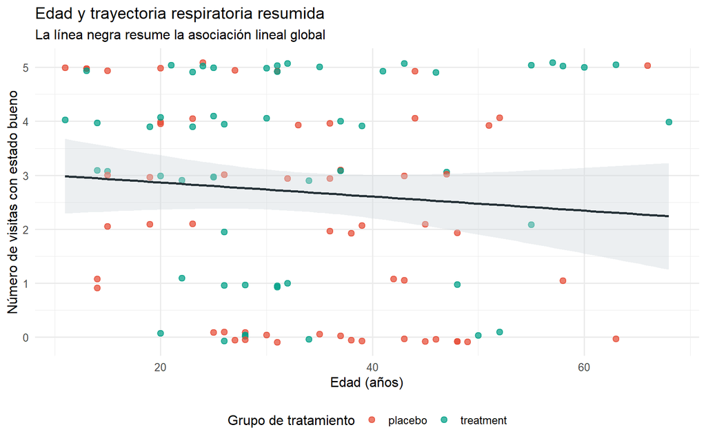

Edad y número de visitas con estado respiratorio bueno.

```r
ggplot(salud_sujeto, aes(x = age, y = visitas_buenas, color = treatment)) + # Ubica edad y número de visitas buenas en los ejes y distingue los grupos por color.
  geom_jitter(width = 0, height = 0.10, alpha = 0.72, size = 2.25) + # Desplaza ligeramente los puntos en vertical para hacer visibles observaciones con el mismo conteo.
  geom_smooth(aes(group = 1), method = "lm", se = TRUE, color = "#263238", fill = "#CFD8DC", linewidth = 1.05) + # Añade una tendencia lineal global como referencia descriptiva, no como modelo causal.
  scale_color_manual(values = paleta_tratamiento, name = "Grupo de tratamiento") + # Mantiene la codificación cromática consistente en toda la ruta clínica.
  scale_y_continuous(breaks = 0:5) + # Muestra explícitamente los únicos valores posibles de la variable de respuesta resumida.
  labs(title = "Edad y trayectoria respiratoria resumida", subtitle = "La línea negra resume la asociación lineal global", x = "Edad (años)", y = "Número de visitas con estado bueno") + # Define etiquetas que respetan la unidad de análisis paciente.
  theme_minimal(base_size = 12) + # Aplica la presentación general.
  theme(legend.position = "bottom") # Ubica la leyenda en la zona inferior del gráfico.
```

```r
cor_edad_visitas <- cor(salud_sujeto$age, salud_sujeto$visitas_buenas) # Calcula la correlación de Pearson entre edad y número de visitas buenas a nivel de paciente.
correlacion_por_tratamiento <- salud_sujeto |> # Parte de la tabla de una fila por sujeto.
  group_by(treatment) |> # Separa la asociación según el grupo asignado.
  summarise(correlacion_edad_visitas = cor(age, visitas_buenas), .groups = "drop") # Calcula la correlación dentro de cada brazo para contrastarla con la relación global.
cor_edad_visitas # Imprime la correlación global para facilitar su interpretación.
```

```
## [1] -0.09298634
```

```r
correlacion_por_tratamiento # Muestra las correlaciones específicas de placebo y tratamiento.
```

| treatment | correlacion_edad_visitas |
| --- | --- |
| placebo | -0.2611839 |
| treatment | 0.0953625 |

### 8.6.1 Análisis conjunto

La correlación global entre edad y número de visitas con estado bueno es aproximadamente **-0.09**. Su signo indica la dirección de la asociación lineal y su magnitud resume cuán alineada está la nube de puntos con una tendencia recta. Como `visitas_buenas` solo toma seis valores enteros, el diagrama de dispersión conserva información que el coeficiente no puede mostrar por sí solo.

Las correlaciones calculadas por tratamiento permiten comprobar si la asociación global es semejante dentro de ambos grupos. Si difieren, ello no autoriza a concluir automáticamente que el tratamiento “modifica” el efecto de la edad; en esta práctica la comparación es exploratoria. El punto metodológico central es que **correlacionar variables exige primero definirlas sobre la misma unidad estadística**.

## 8.7 26. Composición por género y tratamiento en la línea basal

```r
balance_genero <- salud_baseline |> # Parte de una fila por paciente en el momento inicial.
  count(treatment, gender, name = "frecuencia") |> # Cuenta pacientes en cada combinación de tratamiento y género.
  group_by(treatment) |> # Define como denominador el total de pacientes dentro de cada brazo.
  mutate(porcentaje = 100 * frecuencia / sum(frecuencia)) |> # Calcula la composición porcentual por género dentro de cada tratamiento.
  ungroup() # Elimina la agrupación después de construir los porcentajes.
balance_genero # Muestra la tabla de composición basal por género y tratamiento.
```

| treatment | gender | frecuencia | porcentaje |
| --- | --- | --- | --- |
| placebo | female | 40 | 70.17544 |
| placebo | male | 17 | 29.82456 |
| treatment | female | 48 | 88.88889 |
| treatment | male | 6 | 11.11111 |

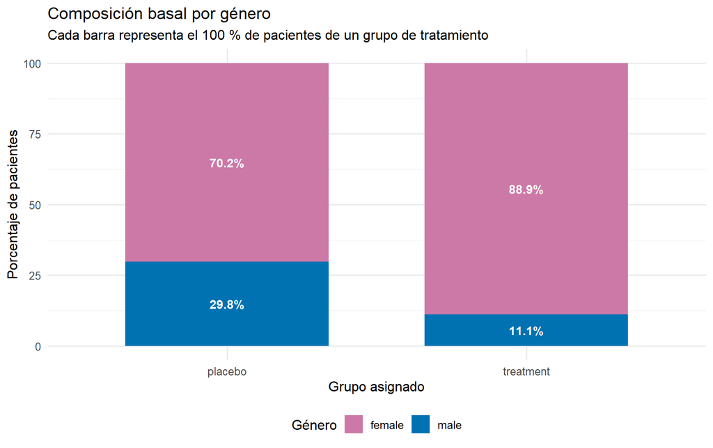

Composición por género de los grupos de tratamiento en la línea basal.

```r
ggplot(balance_genero, aes(x = treatment, y = porcentaje, fill = gender)) + # Inicia un gráfico de composición porcentual para los dos brazos del ensayo.
  geom_col(width = 0.68) + # Dibuja una barra apilada cuya altura total representa el 100 % de cada grupo.
  geom_text(aes(label = paste0(round(porcentaje, 1), "%")), position = position_stack(vjust = 0.5), color = "white", fontface = "bold", size = 3.7) + # Escribe el porcentaje dentro de cada segmento para facilitar comparaciones precisas.
  scale_fill_manual(values = paleta_genero_resp, name = "Género") + # Aplica colores contrastantes y conserva la leyenda porque el relleno codifica género.
  labs(title = "Composición basal por género", subtitle = "Cada barra representa el 100 % de pacientes de un grupo de tratamiento", x = "Grupo asignado", y = "Porcentaje de pacientes") + # Explicita el denominador utilizado en cada barra.
  theme_minimal(base_size = 12) + # Aplica una estética limpia.
  theme(legend.position = "bottom") # Sitúa la leyenda en una zona que no compita con los porcentajes.
```

### 8.7.1 Análisis conjunto

Este gráfico no pretende evaluar una hipótesis de balance, sino enseñar a distinguir **conteos absolutos** de **composición porcentual**. Si los tamaños de los grupos no son exactamente iguales, comparar porcentajes es más informativo que comparar únicamente el número de mujeres y hombres.

También muestra un uso justificado de la leyenda: el eje horizontal ya identifica el tratamiento, mientras que el color representa una segunda variable, el género. En este caso la leyenda añade información indispensable y no es un elemento decorativo.

## 8.8 27. Síntesis del reto clínico

La ruta `respiratory` permite reunir varios aprendizajes en una sola base completa. Primero se identifica la estructura longitudinal; después se construye una tabla basal de una fila por paciente; más adelante se vuelve al formato de visitas para describir la evolución temporal y, finalmente, se resume de nuevo el seguimiento a nivel individual mediante `visitas_buenas`.

El hilo conceptual es:

> **reconocer la unidad de análisis → describir el punto de partida → describir el cambio temporal → resumir el seguimiento por paciente → explorar asociaciones sin confundir filas con individuos.**

Esta secuencia es particularmente útil para un curso introductorio porque muestra que una base puede estar perfectamente completa y, aun así, requerir decisiones estadísticas cuidadosas antes de calcular un promedio o una correlación.

# 9 28. Contraste entre las dos bases reales

| Aspecto | `USairpollution` | `respiratory` |
| --- | --- | --- |
| Unidad de análisis | Ciudad | Registro paciente-momento; paciente cuando se resume a nivel individual |
| Número de observaciones | 41 ciudades | 555 registros de 111 pacientes |
| Datos faltantes | 0 | 0 según la documentación oficial del conjunto |
| Contexto | Contaminación, clima y estructura urbana | Ensayo clínico multicéntrico sobre estado respiratorio |
| Variables categóricas principales | Grupo industrial construido descriptivamente | Tratamiento, género, centro y estado respiratorio |
| Pregunta univariada central | ¿Cómo se distribuye el SO2 entre ciudades? | ¿Cómo se distribuye la edad basal y cómo se resume la trayectoria respiratoria? |
| Comparación por grupos | SO2 según actividad manufacturera | Estado respiratorio y visitas buenas según tratamiento |
| Relación bivariada | Manufactura–SO2 y variables meteorológicas | Edad–número de visitas con estado bueno |
| Precaución principal | Asociación ecológica entre ciudades no implica causalidad individual | Las visitas repetidas del mismo paciente no son observaciones independientes |

Las dos rutas aplican el mismo protocolo de estadística descriptiva, pero las interpretaciones cambian porque **la unidad de análisis, el contexto, la naturaleza de las variables y la estructura de observación son diferentes**. Ese es el aprendizaje de transferencia más importante: el código es reutilizable; la interpretación no puede copiarse mecánicamente.

# 10 29. Producto de cierre de la práctica

Cada equipo selecciona una de las dos bases reales y entrega un bloque breve de R Markdown con los siguientes componentes:

1. **Unidad de análisis y variables:** explique qué representa una fila e identifique una variable categórica y dos cuantitativas.
2. **Completitud:** confirme con una instrucción de R que la base no contiene datos faltantes.
3. **Resumen:** reporte centro y dispersión de una variable cuantitativa y justifique por qué utiliza media/desviación estándar o mediana/IQR.
4. **Visualización:** incluya dos gráficos que respondan preguntas diferentes. El color debe representar información, no ser únicamente decorativo.
5. **Relación:** explore una asociación entre dos variables cuantitativas mediante dispersión y correlación.
6. **Interpretación:** escriba un máximo de 180 palabras que incluya un hallazgo univariado, una comparación entre grupos, una relación bivariada y una advertencia sobre el alcance descriptivo de las conclusiones.

## 10.1 Exit ticket

Responda en una frase cada punto:

1. ¿Qué decisión sobre el tipo o significado de una variable fue esencial antes de analizarla?
2. ¿En qué caso de la práctica la mediana resultó más informativa que la media, y por qué?
3. ¿Qué gráfico comunicaría mejor el principal hallazgo de su base y qué evidencia concreta contiene?

# 11 30. Recomendaciones metodológicas para el estudiante

Una práctica de estadística descriptiva no consiste en producir muchas salidas. Cada bloque de código debe responder una pregunta y cada gráfico debe interpretarse utilizando elementos observables: posición, dispersión, forma, solapamiento, pendiente, concentración o diferencias de proporciones.

Evite expresiones vagas como “los datos están bien”, “la gráfica sube” o “hay mucha diferencia”. Sustitúyalas por afirmaciones verificables: “la mediana supera a…”, “el 50 % central se ubica entre…”, “la nube muestra una tendencia positiva con amplia dispersión”, o “la proporción de salud buena/excelente es mayor en…”.

También debe distinguir claramente entre **descripción, asociación e inferencia causal**. Esta práctica se concentra en las dos primeras. Los datos pueden mostrar que dos variables están asociadas, pero identificar por qué ocurre esa asociación requeriría diseño de estudio, teoría sustantiva y métodos inferenciales adicionales.

# 12 31. Referencias y documentación

- Hothorn, T. y Everitt, B. S. `HSAUR3`: *A Handbook of Statistical Analyses Using R (3rd Edition)*. CRAN. Documentación de `USairpollution` y `respiratory`: https://CRAN.R-project.org/package=HSAUR3.
- Wickham, H., François, R., Henry, L., Müller, K. y Vaughan, D. `dplyr`: gramática de manipulación de datos. https://dplyr.tidyverse.org/.
- Wickham, H. et al. `ggplot2`: sistema de visualización basado en la gramática de gráficos. https://ggplot2.tidyverse.org/.
- R Core Team. *R: A Language and Environment for Statistical Computing*. https://www.R-project.org/.

## 12.1 Idea final

> **Una descripción estadística de calidad no se mide por la cantidad de comandos ejecutados. Se reconoce porque cada número y cada gráfico responden una pregunta, respetan la naturaleza de los datos y conducen a una conclusión cuyo alcance está claramente delimitado.**